# Análisis Exploratorio de Datos (EDA) - Proyecto de Transporte - Dataset Cycling

### General: Objetivos del Proyecto y Definición de Variables

El objetivo principal de este proyecto es desarrollar un modelo basado en **Máquinas de Vectores de Soporte (SVM)** para predecir el **modo de transporte** utilizado por un individuo en función de los datos recopilados por sensores de dispositivos móviles. Se busca analizar cómo las diferentes señales captadas por el acelerómetro, giróscopo, barómetro, GPS y magnetómetro pueden ser utilizadas para inferir con precisión el medio de transporte en uso.

Para lograr esto, se cuenta con un conjunto de datos que incluye:

1. **Registro Temporal**
   - Cada observación está asociada a un instante de tiempo específico.
2. **Datos de Movimiento y Orientación**
   - **Acelerómetro**: Componentes X, Y, Z del vector aceleración.
   - **Giróscopo**: Velocidad angular en los ejes X, Y, Z y su derivada.
   - **Matriz de Rotación y Cuaterniones**: Representan la orientación tridimensional del dispositivo.
3. **Datos de Ubicación y Contexto**
   - **GPS**: Coordenadas de latitud y longitud, velocidad, altitud y rumbo.
   - **Presión Atmosférica**: Valores obtenidos del barómetro, junto con la altitud relativa.
   - **Campo Magnético Terrestre**: Medición en los ejes X, Y, Z.
4. **Variables Categóricas**
   - **Modo de Transporte**: La categoría que se busca predecir (caminar, bicicleta, automóvil, etc.).
   - **Nivel de Confianza**: Un indicador de la precisión estimada para la clasificación del transporte en los datos originales.

### Objetivo Notebook:

El análisis exploratorio de datos (EDA) busca comprender la estructura del dataset, identificar patrones y evaluar la calidad de los datos antes de proceder con el modelado. Se incluyen tareas como:

- **Identificación y tratamiento de outliers univariantes y multivariantes.**
- **Evaluación de la normalidad y distribución de las variables.**
- **Exploración de la correlación entre variables para determinar redundancias o relaciones clave.**
- **Selección de variables relevantes para el modelo.**

# **1. Carga de librerías**

```r
# Lista de paquetes necesarios
necessary_packages <- c("dplyr", "ggplot2", "DataExplorer", "naniar",
                        "moments", "psych", "caret", "lubridate", "chemometrics",
                        "tidyr", "tidyverse", "cowplot", "car")

# Instalar paquetes que no están instalados
new_packages <- necessary_packages[!(necessary_packages %in% installed.packages()[, "Package"])]
if (length(new_packages) > 0) {
  install.packages(new_packages)
}

# Cargar todos los paquetes
lapply(necessary_packages, library, character.only = TRUE)
```

[output not shown]

[output cut: 9 more lines]

[output not shown]

```r
# Cargar las librerías
library(lubridate)
library(dplyr)
library(ggplot2)
library(naniar)
library(moments)
library(psych)
library(caret)
library(reshape2)
library(geosphere)
library(zoo)
# Cargar librerías necesarias
library(ggplot2)
library(gridExtra) # Para organizar múltiples gráficos
library(ggpubr)    # Para Q-Q plots
library(chemometrics)
```

# 2. Cargar el dataset

```r
# Ruta del archivo CSV (modificar según tu sistema)
ruta_dataset <- "C:/Users/Lenovo/Documents/IT Academy/Datos proyecto 8/proyect8/input_data/50Hz-v5-20230911-124152-30s-bici.csv"

data <- read.csv(ruta_dataset)

# Resumen del dataset
cat("### Información General del Dataset")
```

```
### Información General del Dataset
```

```r
dim(data) # Dimensiones del dataset
```

```
[1] 2985   44
```

```r
str(data) # Estructura del dataset
```

```
'data.frame':   2985 obs. of  44 variables:
 $ Timestamp               : chr  "11-Sep-2023 12:42:12.879" "11-Sep-2023 12:42:12.889" "11-Sep-2023 12:42:12.898" "11-Sep-2023 12:42:12.909" ...
 $ accelX.g.               : num  0.749 0.687 0.662 0.659 0.676 ...
 $ accelY.g.               : num  0.0179 0.0033 0.0041 -0.006 -0.0239 ...
 $ accelZ.g.               : num  0.662 0.645 0.648 0.674 0.728 ...
 $ accelUserX.g.           : num  0.0155 -0.0595 -0.1046 -0.1169 -0.1088 ...
 $ accelUserY.g.           : num  -0.0749 -0.0679 -0.07 -0.0601 -0.0658 ...
 $ accelUserZ.g.           : num  0.0835 0.0408 0.0234 0.0248 0.0534 ...
 $ gyroX.rad.s.            : num  -0.93 -0.905 -0.914 -0.905 -0.86 ...
 $ gyroY.rad.s.            : num  0.613 0.77 0.844 0.883 0.945 ...
 $ gyroZ.rad.s.            : num  0.426 0.428 0.438 0.459 0.49 ...
 $ Roll.rads.              : num  2.23 2.23 2.24 2.25 2.26 ...
 $ Pitch.rads.             : num  -0.0904 -0.0815 -0.0726 -0.0634 -0.0543 -0.0451 -0.0359 -0.0267 -0.0173 -0.0079 ...
 $ Yaw.rads.               : num  -3.09 -3.08 -3.08 -3.08 -3.07 ...
 $ m11                     : num  0.605 0.611 0.617 0.624 0.632 ...
```

[output cut: 30 more lines]

```r
summary(data) # Resumen estadístico básico
```

```
  Timestamp           accelX.g.         accelY.g.         accelZ.g.       accelUserX.g.      accelUserY.g.       accelUserZ.g.       gyroX.rad.s.       gyroY.rad.s.       gyroZ.rad.s.
 Length:2985        Min.   :-0.1799   Min.   :-0.3039   Min.   :-0.2683   Min.   :-0.63060   Min.   :-0.292600   Min.   :-0.63610   Min.   :-1.79330   Min.   :-4.39540   Min.   :-3.76950
 Class :character   1st Qu.: 0.7355   1st Qu.: 0.0723   1st Qu.: 0.2678   1st Qu.:-0.04360   1st Qu.:-0.056700   1st Qu.:-0.07290   1st Qu.:-0.30380   1st Qu.:-0.28280   1st Qu.:-0.17660
 Mode  :character   Median : 0.8477   Median : 0.2906   Median : 0.3781   Median : 0.00580   Median :-0.008800   Median :-0.00870   Median :-0.00020   Median :-0.00350   Median : 0.00280
                    Mean   : 0.8027   Mean   : 0.2699   Mean   : 0.4064   Mean   : 0.01387   Mean   : 0.003483   Mean   :-0.01992   Mean   :-0.02185   Mean   :-0.01767   Mean   :-0.00224
                    3rd Qu.: 0.9175   3rd Qu.: 0.4778   3rd Qu.: 0.5598   3rd Qu.: 0.06600   3rd Qu.: 0.050800   3rd Qu.: 0.04420   3rd Qu.: 0.28110   3rd Qu.: 0.31090   3rd Qu.: 0.20400
                    Max.   : 2.0890   Max.   : 1.0647   Max.   : 0.9785   Max.   : 1.24300   Max.   : 0.434900   Max.   : 0.60770   Max.   : 1.65650   Max.   : 3.31610   Max.   : 2.28740
   Roll.rads.     Pitch.rads.        Yaw.rads.           m11              m12               m13               m21               m22               m23               m31
 Min.   :1.665   Min.   :-0.8318   Min.   :-3.142   Min.   :0.2404   Min.   :-0.2943   Min.   :-0.9478   Min.   :-0.5359   Min.   :-0.9999   Min.   :-0.7391   Min.   :-0.9698
 1st Qu.:1.900   1st Qu.:-0.5265   1st Qu.: 2.582   1st Qu.:0.3974   1st Qu.: 0.0761   1st Qu.:-0.8758   1st Qu.:-0.2666   1st Qu.:-0.9773   1st Qu.:-0.5025   1st Qu.:-0.8939
 Median :1.998   Median :-0.2931   Median : 2.853   Median :0.4598   Median : 0.2156   Median :-0.8351   Median :-0.1172   Median :-0.9444   Median :-0.2889   Median :-0.8540
 Mean   :2.057   Mean   :-0.2789   Mean   : 1.538   Mean   :0.5043   Mean   : 0.1961   Mean   :-0.7887   Mean   :-0.1380   Mean   :-0.9004   Mean   :-0.2661   Mean   :-0.8112
 3rd Qu.:2.141   3rd Qu.:-0.1033   3rd Qu.: 3.031   3rd Qu.:0.5571   3rd Qu.: 0.3340   3rd Qu.:-0.7462   3rd Qu.:-0.0126   3rd Qu.:-0.8219   3rd Qu.:-0.1031   3rd Qu.:-0.7850
 Max.   :2.836   Max.   : 0.2206   Max.   : 3.142   Max.   :0.9478   Max.   : 0.6333   Max.   :-0.2981   Max.   : 0.1723   Max.   :-0.6293   Max.   : 0.2188   Max.   :-0.3093
      m32               m33                qX               qY                qZ                qW               Lat             Long         Speed.m.s.      TrueHeading        Alt.m.
 Min.   :-0.2094   Min.   :-0.9465   Min.   :0.7256   Min.   :-0.1563   Min.   :-0.6111   Min.   :-0.4122   Min.   :41.39   Min.   :2.122   Min.   :0.0266   Min.   : 68.0   Min.   :67.47
 1st Qu.: 0.0172   1st Qu.:-0.5334   1st Qu.:0.8008   1st Qu.:-0.0303   1st Qu.:-0.5413   1st Qu.:-0.2727   1st Qu.:41.39   1st Qu.:2.123   1st Qu.:1.0367   1st Qu.:103.9   1st Qu.:67.66
 Median : 0.2240   Median :-0.3850   Median :0.8280   Median : 0.0239   Median :-0.5145   Median :-0.1552   Median :41.39   Median :2.123   Median :1.5868   Median :124.3   Median :67.66
 Mean   : 0.2167   Mean   :-0.4264   Mean   :0.8390   Mean   : 0.0194   Mean   :-0.4830   Mean   :-0.1537   Mean   :41.39   Mean   :2.123   Mean   :1.7389   Mean   :125.2   Mean   :67.63
 3rd Qu.: 0.4107   3rd Qu.:-0.2979   3rd Qu.:0.8730   3rd Qu.: 0.0695   3rd Qu.:-0.4671   3rd Qu.:-0.0417   3rd Qu.:41.39   3rd Qu.:2.123   3rd Qu.:2.8932   3rd Qu.:147.4   3rd Qu.:67.66
 Max.   : 0.6642   Max.   :-0.0776   Max.   :0.9854   Max.   : 0.1566   Max.   :-0.1542   Max.   : 0.1049   Max.   :41.39   Max.   :2.123   Max.   :3.6376   Max.   :173.7   Max.   :67.66
 HorizontalAccuracy.m. VerticalAccuracy.m.     Course       ActivityType       ActivityConfidence Pressure.kilopascals. RelativeAltitude.meters.    magX.µT.         magY.µT.
 Min.   : 6.000        Min.   :3           Min.   : 54.90   Length:2985        Length:2985        Min.   :100.7         Min.   :-1.3159          Min.   : 94.49   Min.   : 95.44
 1st Qu.: 6.000        1st Qu.:3           1st Qu.: 73.80   Class :character   Class :character   1st Qu.:100.7         1st Qu.:-1.0543          1st Qu.:100.28   1st Qu.:109.30
 Median : 6.000        Median :3           Median : 95.50   Mode  :character   Mode  :character   Median :100.7         Median :-0.6289          Median :103.15   Median :115.67
 Mean   : 7.569        Mean   :3           Mean   : 88.94                                         Mean   :100.7         Mean   :-0.6291          Mean   :102.44   Mean   :114.55
 3rd Qu.: 8.000        3rd Qu.:3           3rd Qu.:101.20                                         3rd Qu.:100.7         3rd Qu.:-0.2378          3rd Qu.:104.60   3rd Qu.:120.04
 Max.   :16.000        Max.   :3           Max.   :108.60                                         Max.   :100.7         Max.   : 0.2405          Max.   :106.26   Max.   :130.76
    magZ.µT.       calMagX.µT.     calMagY.µT.       calMagZ.µT.
 Min.   :-404.6   Min.   :34.70   Min.   :-12.877   Min.   :-19.062
 1st Qu.:-397.1   1st Qu.:40.59   1st Qu.:  1.127   1st Qu.:-11.339
 Median :-393.8   Median :43.43   Median :  7.513   Median : -8.062
 Mean   :-390.5   Mean   :42.70   Mean   :  6.529   Mean   : -4.793
 3rd Qu.:-386.8   3rd Qu.:44.82   3rd Qu.: 12.016   3rd Qu.: -1.241
 Max.   :-360.5   Max.   :46.63   Max.   : 22.848   Max.   : 25.217
```

La variable **`Timestamp`** está almacenada como **cadena de texto (`chr`)**, lo que dificulta su manipulación y análisis temporal. Para facilitar su uso en el procesamiento de datos y visualización, se convierte al formato **`POSIXct`**, permitiendo cálculos de intervalos de tiempo, filtrado y una mejor representación en gráficos.

En cuanto a la columna **`ActivityType`**, contiene valores **inconsistentes** como **“unknown”** y **“walking”**, a pesar de que el dataset representa exclusivamente actividades de **cycling**. Para garantizar la coherencia en los datos, estos valores se reemplazan y categorizan correctamente como **“cycling”**.

Adicionalmente, se han identificado variables como **`Lat`**, **`Long`**, **`Speed.m.s.`**, **`TrueHeading`**, **`Alt.m.`**, **`HorizontalAccuracy.m.`**, **`VerticalAccuracy.m.`** y **`Course`** que no se encuentran en otros dataset y **no pueden ser calculadas, asi como** se requiere **unicidad en la estructura de los datos** para asegurar una integración adecuada, se decide eliminarlas, manteniendo solo las variables que pueden ser comparadas o utilizadas en el análisis conjunto.

#### 2.1. Convertir Timestamp de chr

```r
head(data$Timestamp)
```

```
[1] "11-Sep-2023 12:42:12.879" "11-Sep-2023 12:42:12.889" "11-Sep-2023 12:42:12.898" "11-Sep-2023 12:42:12.909" "11-Sep-2023 12:42:12.919" "11-Sep-2023 12:42:12.929"
```

```r
# Convertir Timestamp con parse_date_time
data <- data %>%
  mutate(Timestamp = parse_date_time(Timestamp, orders = "dmy HMSOS"))

# Verificar el resultado
head(data$Timestamp)
```

```
[1] "2020-09-11 23:12:12 UTC" "2020-09-11 23:12:12 UTC" "2020-09-11 23:12:12 UTC" "2020-09-11 23:12:12 UTC" "2020-09-11 23:12:12 UTC" "2020-09-11 23:12:12 UTC"
```

```r
class(data$Timestamp)  # Debería ser POSIXc
```

```
[1] "POSIXct" "POSIXt"
```

#### 2.2. Eliminar variables

```r
# Eliminar las columnas específicas del dataset
data <- data %>%
  select(-Lat, -Long, -Speed.m.s., -TrueHeading, -Alt.m., -HorizontalAccuracy.m., -VerticalAccuracy.m., -Course)
# Verificar las columnas restantes
colnames(data)
```

```
 [1] "Timestamp"                "accelX.g."                "accelY.g."                "accelZ.g."                "accelUserX.g."            "accelUserY.g."            "accelUserZ.g."
 [8] "gyroX.rad.s."             "gyroY.rad.s."             "gyroZ.rad.s."             "Roll.rads."               "Pitch.rads."              "Yaw.rads."                "m11"
[15] "m12"                      "m13"                      "m21"                      "m22"                      "m23"                      "m31"                      "m32"
[22] "m33"                      "qX"                       "qY"                       "qZ"                       "qW"                       "ActivityType"             "ActivityConfidence"
[29] "Pressure.kilopascals."    "RelativeAltitude.meters." "magX.µT."                 "magY.µT."                 "magZ.µT."                 "calMagX.µT."              "calMagY.µT."
[36] "calMagZ.µT."
```

#### 2.3. Categorizacion de la variable `ActivityType`

```r
# Reemplazar valores inconsistentes en la columna ActivityType
data <- data %>%
  mutate(ActivityType = ifelse(ActivityType %in% c("Unknown", "Walking"), "Cycling", ActivityType))

# Verificar los valores únicos después del reemplazo
table(data$ActivityType)
```

```
Cycling
   2985
```

```r
str(data)
```

```
'data.frame':   2985 obs. of  36 variables:
 $ Timestamp               : POSIXct, format: "2020-09-11 23:12:12" "2020-09-11 23:12:12" "2020-09-11 23:12:12" "2020-09-11 23:12:12" ...
 $ accelX.g.               : num  0.749 0.687 0.662 0.659 0.676 ...
 $ accelY.g.               : num  0.0179 0.0033 0.0041 -0.006 -0.0239 ...
 $ accelZ.g.               : num  0.662 0.645 0.648 0.674 0.728 ...
 $ accelUserX.g.           : num  0.0155 -0.0595 -0.1046 -0.1169 -0.1088 ...
 $ accelUserY.g.           : num  -0.0749 -0.0679 -0.07 -0.0601 -0.0658 ...
 $ accelUserZ.g.           : num  0.0835 0.0408 0.0234 0.0248 0.0534 ...
 $ gyroX.rad.s.            : num  -0.93 -0.905 -0.914 -0.905 -0.86 ...
 $ gyroY.rad.s.            : num  0.613 0.77 0.844 0.883 0.945 ...
 $ gyroZ.rad.s.            : num  0.426 0.428 0.438 0.459 0.49 ...
 $ Roll.rads.              : num  2.23 2.23 2.24 2.25 2.26 ...
 $ Pitch.rads.             : num  -0.0904 -0.0815 -0.0726 -0.0634 -0.0543 -0.0451 -0.0359 -0.0267 -0.0173 -0.0079 ...
 $ Yaw.rads.               : num  -3.09 -3.08 -3.08 -3.08 -3.07 ...
 $ m11                     : num  0.605 0.611 0.617 0.624 0.632 ...
```

[output cut: 22 more lines]

# 3. Estadísticas Descriptivas

Las estadísticas descriptivas ofrecen una visión inicial sobre el rango, la distribución y los valores típicos de las variables. Esto permite identificar patrones generales y posibles anomalías.

## **3.1 Variables Numéricas**

Se analizan las variables numéricas mediante histogramas y medidas descriptivas para evaluar su distribución y detectar valores atípicos.

```r
# Seleccionar columnas numéricas
num_data <- data %>% select(where(is.numeric))

# Verificar si hay columnas numéricas
if (ncol(num_data) > 0) {
  cat("### Estadísticas para Variables Numéricas\n")

  # Imprimir estadísticas descriptivas básicas
  print(describe(num_data)) # Estadísticas básicas

} else {
  cat("No hay variables numéricas en el dataset.\n")
}
```

```
### Estadísticas para Variables Numéricas
```

|  | vars | n | mean | sd | median | trimmed | mad | min | max | range | skew | kurtosis | se |
| --- | --- | --- | --- | --- | --- | --- | --- | --- | --- | --- | --- | --- | --- |
| accelX.g. | 1 | 2985 | 0.80 | 0.22 | 0.85 | 0.83 | 0.12 | -0.18 | 2.09 | 2.27 | -1.14 | 4.47 | 0.00 |
| accelY.g. | 2 | 2985 | 0.27 | 0.27 | 0.29 | 0.27 | 0.29 | -0.30 | 1.06 | 1.37 | -0.18 | -0.70 | 0.00 |
| accelZ.g. | 3 | 2985 | 0.41 | 0.20 | 0.38 | 0.40 | 0.21 | -0.27 | 0.98 | 1.25 | 0.15 | -0.46 | 0.00 |
| accelUserX.g. | 4 | 2985 | 0.01 | 0.14 | 0.01 | 0.01 | 0.08 | -0.63 | 1.24 | 1.87 | 1.08 | 9.52 | 0.00 |
| accelUserY.g. | 5 | 2985 | 0.00 | 0.09 | -0.01 | 0.00 | 0.08 | -0.29 | 0.43 | 0.73 | 0.72 | 1.13 | 0.00 |
| accelUserZ.g. | 6 | 2985 | -0.02 | 0.13 | -0.01 | -0.01 | 0.09 | -0.64 | 0.61 | 1.24 | -0.52 | 2.68 | 0.00 |
| gyroX.rad.s. | 7 | 2985 | -0.02 | 0.49 | 0.00 | -0.01 | 0.43 | -1.79 | 1.66 | 3.45 | -0.27 | 0.57 | 0.01 |
| gyroY.rad.s. | 8 | 2985 | -0.02 | 0.96 | 0.00 | 0.01 | 0.44 | -4.40 | 3.32 | 7.71 | -0.57 | 4.20 | 0.02 |
| gyroZ.rad.s. | 9 | 2985 | 0.00 | 0.62 | 0.00 | 0.01 | 0.29 | -3.77 | 2.29 | 6.06 | -0.46 | 4.47 | 0.01 |
| Roll.rads. | 10 | 2985 | 2.06 | 0.26 | 2.00 | 2.03 | 0.16 | 1.66 | 2.84 | 1.17 | 1.07 | 0.72 | 0.00 |

[output cut: 23 more lines]

```r
NA
```

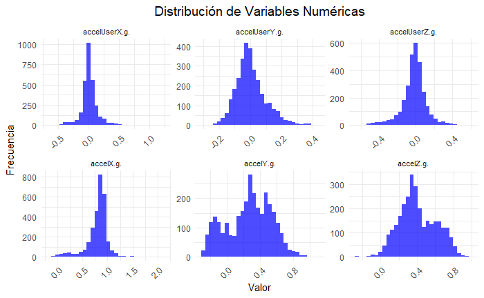

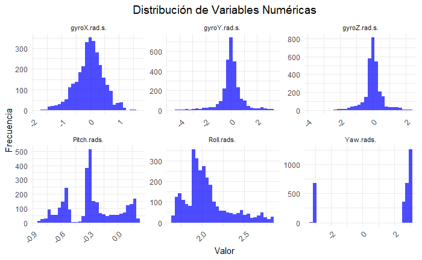

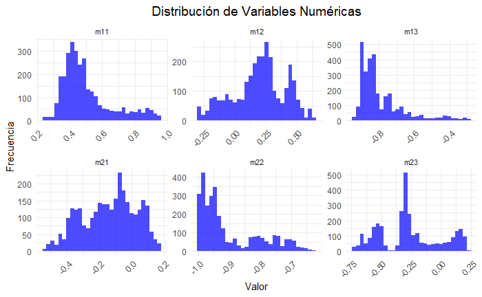

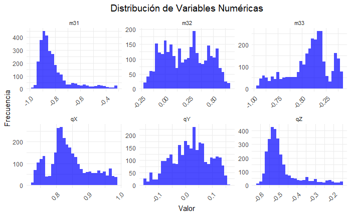

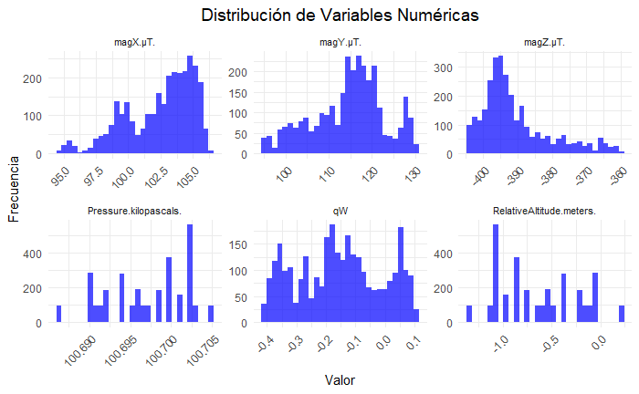

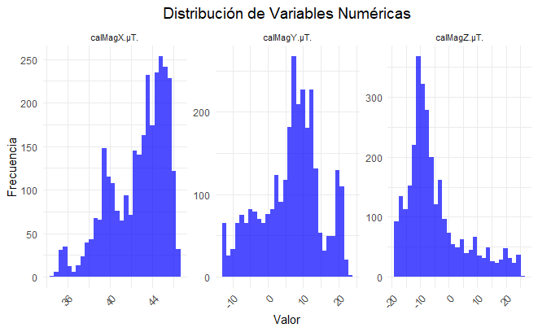

```r
# cargar tidyr si es necesario
library(tidyr)

# Visualización: Histogramas de Variables Numéricas
# Dividir las variables en grupos de 9
variable_groups <- split(names(num_data), ceiling(seq_along(names(num_data)) / 6))

for (group in variable_groups) {
  # Filtrar las variables del grupo actual
  group_data <- num_data %>% select(all_of(group))

  # Convertir a formato largo
  group_data_long <- group_data %>%
    pivot_longer(cols = everything(), names_to = "Variable", values_to = "Valor")

  # Crear los gráficos
  print(
    ggplot(group_data_long, aes(x = Valor)) +
      geom_histogram(bins = 30, fill = "blue", alpha = 0.7) +
      facet_wrap(~ Variable, scales = "free", ncol = 3) +
      theme_minimal() +
      theme(
        strip.text = element_text(size = 8),
        axis.text.x = element_text(angle = 45, hjust = 1),
        plot.title = element_text(size = 14, hjust = 0.5)
      ) +
      labs(title = "Distribución de Variables Numéricas",
           x = "Valor",
           y = "Frecuencia")
  )
}
```

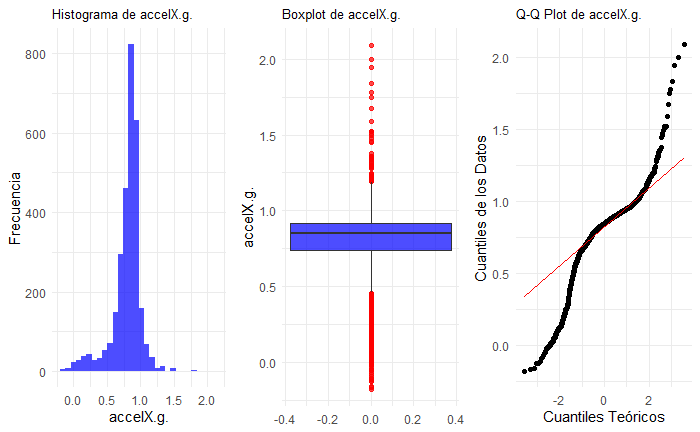

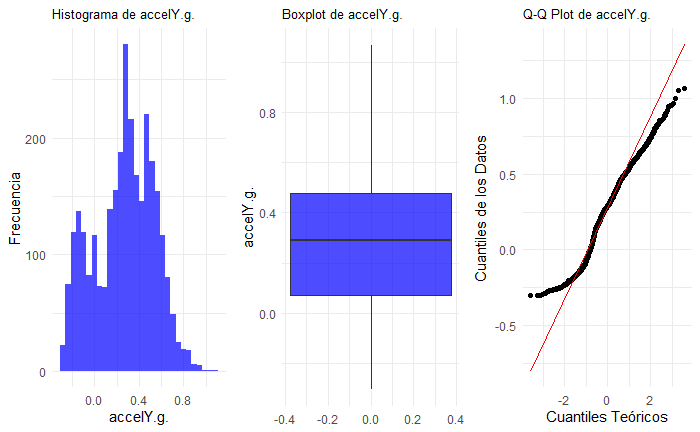

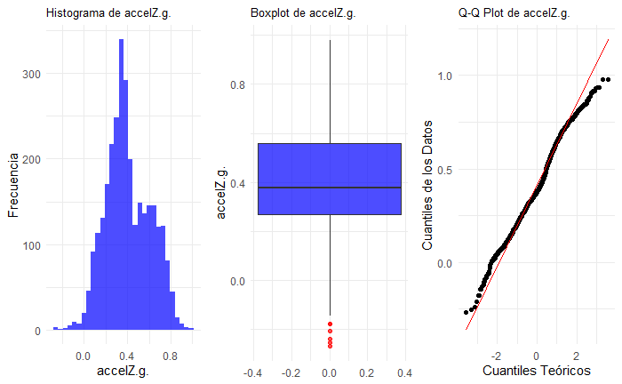

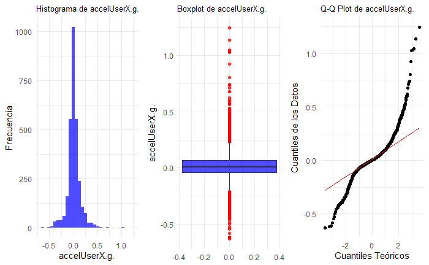

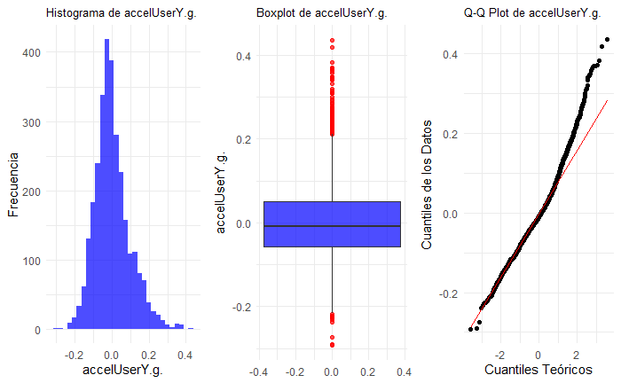

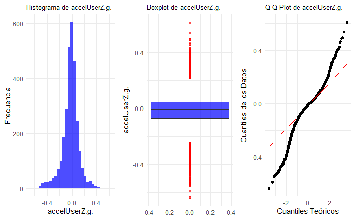

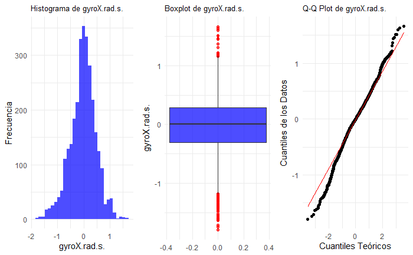

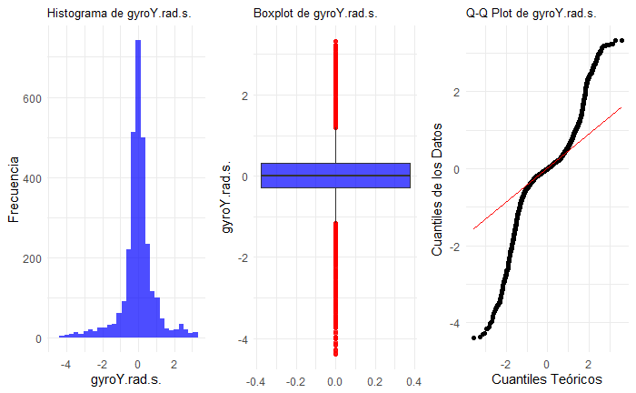

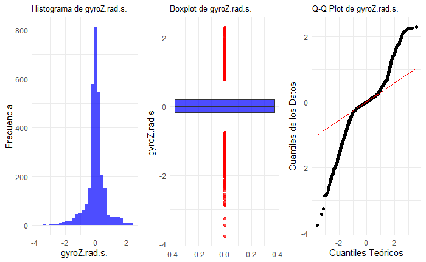

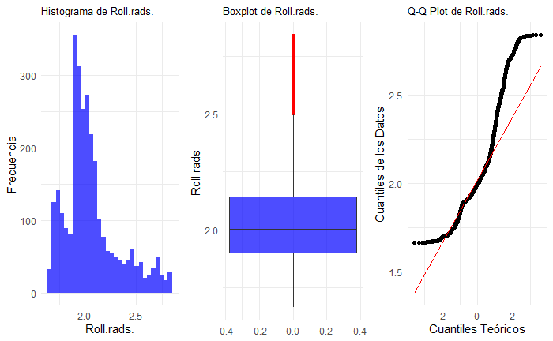

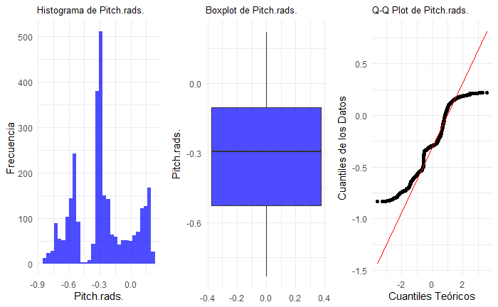

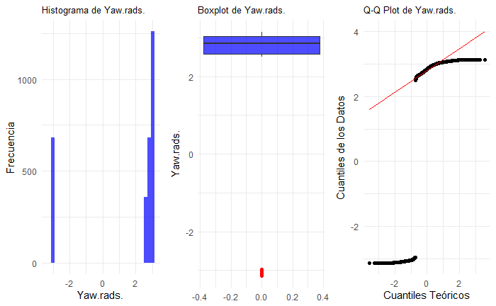

[21 more figures not shown]

```r
# Cargar librerías necesarias
library(tidyverse)
library(cowplot)

# Eliminar valores NA en num_data
num_data_clean <- num_data %>% drop_na()

# Confirmar que hay variables numéricas
if (ncol(num_data_clean) > 0) {
  # Iterar sobre las variables numéricas
  for (var in names(num_data_clean)) {
    # Crear histogramas
    hist_plot <- ggplot(num_data_clean, aes(x = !!sym(var))) +
      geom_histogram(bins = 30, fill = "blue", alpha = 0.7) +
      theme_minimal() +
      labs(title = paste("Histograma de", var), x = var, y = "Frecuencia") +
      theme(plot.title = element_text(size = 10))  # Ajuste de tamaño de título

    # Crear boxplots
    box_plot <- ggplot(num_data_clean, aes(y = !!sym(var))) +
      geom_boxplot(fill = "blue", alpha = 0.7, outlier.color = "red") +
      theme_minimal() +
      labs(title = paste("Boxplot de", var), y = var) +
      theme(plot.title = element_text(size = 10))  # Ajuste de tamaño de título

    # Crear Q-Q plots
    qq_plot <- ggplot(num_data_clean, aes(sample = !!sym(var))) +
      stat_qq() +
      stat_qq_line(color = "red") +
      theme_minimal() +
      labs(title = paste("Q-Q Plot de", var), x = "Cuantiles Teóricos", y = "Cuantiles de los Datos") +
      theme(plot.title = element_text(size = 10))  # Ajuste de tamaño de título

    # Mostrar los gráficos en una cuadrícula
    print(plot_grid(hist_plot, box_plot, qq_plot, ncol = 3))
  }
} else {
  cat("No hay variables numéricas en el dataset.\n")
}
```

```r
NA
NA
```

A partir del análisis estadístico descriptivo proporcionado en la tabla, se pueden observar las siguientes características de las variables:

### **Errores Estándar (SE)**

- Los valores del error estándar (SE) son bajos en general, lo que indica que las medias están bien representadas para el tamaño de muestra proporcionado.

### **Recomendaciones**

Este análisis ayuda a identificar distribuciones, posibles transformaciones y las variables que requieren más atención en los siguientes pasos del proceso analítico.

## 3.2 Variables Categóricas

Las variables categóricas se analizan para evaluar el balance de las clases, especialmente la variable objetivo.

```r
# Convertir las columnas character restantes en factor
data <- data %>%
  mutate(across(where(is.character), as.factor))

# Seleccionar las variables categóricas
cat_data <- data %>% select(where(is.factor))

# Verificar las estadísticas de variables categóricas
if (ncol(cat_data) > 0) {
  cat("### Estadísticas para Variables Categóricas\n")
  print(sapply(cat_data, table))
}
```

```
### Estadísticas para Variables Categóricas
$ActivityType

Cycling
   2985

$ActivityConfidence

High  Med
2138  847
```

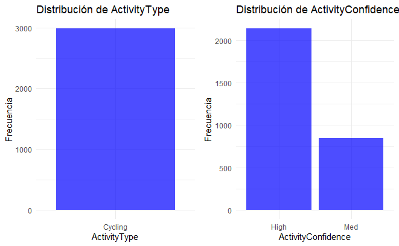

```r
# Gráficos de barras para cada variable categórica
# Crear una lista para almacenar los gráficos
plot_list <- list()

# Crear gráficos de barras para cada variable categórica y almacenarlos en la lista
for (var in names(cat_data)) {
  p <- ggplot(cat_data, aes_string(x = var)) +
    geom_bar(fill = "blue", alpha = 0.7) +
    theme_minimal() +
    labs(title = paste("Distribución de", var),
         x = var,
         y = "Frecuencia") +
    theme(axis.text.x = element_text(angle = 0, hjust = 0.5)) # Categorías horizontales

  # Agregar el gráfico a la lista
  plot_list[[var]] <- p
}
# Combinar todos los gráficos en una sola hoja
grid.arrange(grobs = plot_list, ncol = 2) # Ajusta ncol para cambiar las columnas
```

# 4. Análisis de Valores Faltantes y Outliers

## 4.1 Detección de Valores faltantes

Identificar valores faltantes es crucial porque pueden afectar el rendimiento del modelo predictivo. Este paso ayuda a decidir estrategias para imputar o manejar estos valores.

```r
cat("### Análisis de Valores Faltantes\n")
```

```
### Análisis de Valores Faltantes
```

```r
# Resumen de valores faltantes por columna
print(sapply(data, function(x) sum(is.na(x))))
```

```
               Timestamp                accelX.g.                accelY.g.                accelZ.g.            accelUserX.g.            accelUserY.g.            accelUserZ.g.
                       0                        0                        0                        0                        0                        0                        0
            gyroX.rad.s.             gyroY.rad.s.             gyroZ.rad.s.               Roll.rads.              Pitch.rads.                Yaw.rads.                      m11
                       0                        0                        0                        0                        0                        0                        0
                     m12                      m13                      m21                      m22                      m23                      m31                      m32
                       0                        0                        0                        0                        0                        0                        0
                     m33                       qX                       qY                       qZ                       qW             ActivityType       ActivityConfidence
                       0                        0                        0                        0                        0                        0                        0
   Pressure.kilopascals. RelativeAltitude.meters.                 magX.µT.                 magY.µT.                 magZ.µT.              calMagX.µT.              calMagY.µT.
                       0                        0                        0                        0                        0                        0                        0
             calMagZ.µT.
                       0
```

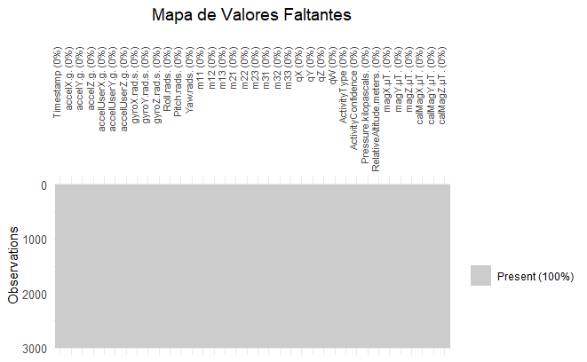

```r
# Visualización de valores faltantes mejorada
vis_miss(data) +
  ggtitle("Mapa de Valores Faltantes") +
  theme_minimal() +
  theme(
    axis.text.x = element_text(angle = 90, hjust = 1, size = 8), # Ajuste de las etiquetas del eje X
    axis.text.y = element_text(size = 10),                       # Ajuste de las etiquetas del eje Y
    plot.title = element_text(hjust = 0.5, size = 14)            # Centrar y ajustar tamaño del título
  )
```

```r
NA
NA
```

## 4.2 Detección de Outliers Univariantes

Usaremos el rango intercuartílico (IQR) para identificar outliers y calcular el porcentaje de valores extremos en cada variable numérica.

```r
if (ncol(num_data) > 0) {
  cat("### Análisis de Outliers\n")

  # Cálculo de outliers por IQR
  outlier_detection <- num_data %>%
    summarise(across(everything(), ~ {
      q1 <- quantile(.x, 0.25, na.rm = TRUE)
      q3 <- quantile(.x, 0.75, na.rm = TRUE)
      iqr <- q3 - q1
      sum(.x < (q1 - 1.5 * iqr) | .x > (q3 + 1.5 * iqr), na.rm = TRUE) / length(.x) * 100
    }))

  # Transponer la tabla
  outlier_detection <- as.data.frame(t(outlier_detection))
  outlier_detection$Variable <- rownames(outlier_detection)
  rownames(outlier_detection) <- NULL

  # Reordenar las columnas
  outlier_detection <- outlier_detection %>%
    select(Variable, `Outliers (%)` = V1) %>%
    arrange(desc(`Outliers (%)`))  # Ordenar de mayor a menor

  # Mostrar la tabla
  print(outlier_detection)
}
```

```
### Análisis de Outliers
```

| Variable | Outliers (%) |
| --- | --- |
| Yaw.rads. | 22.948074 |
| gyroZ.rad.s. | 14.572864 |
| gyroY.rad.s. | 13.869347 |
| qZ | 12.462312 |
| accelUserX.g. | 10.117253 |
| m31 | 9.748744 |
| accelX.g. | 8.978224 |
| m11 | 8.810720 |
| Roll.rads. | 8.777219 |
| accelUserZ.g. | 8.710218 |

[output cut: 23 more lines]

**Visualización de Outliers**

Utilizaremos boxplots para visualizar los outliers en cada variable numérica.

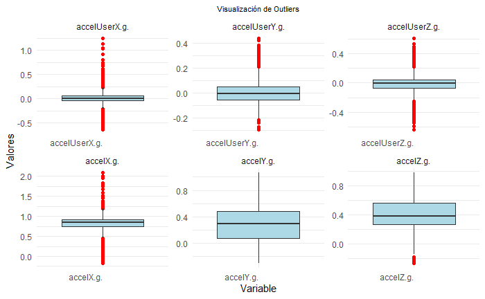

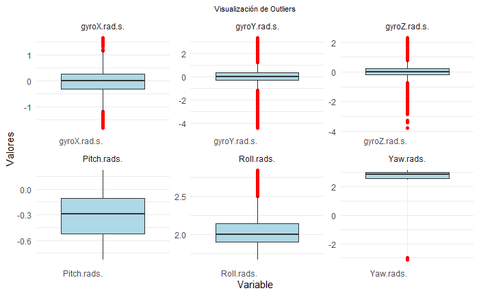

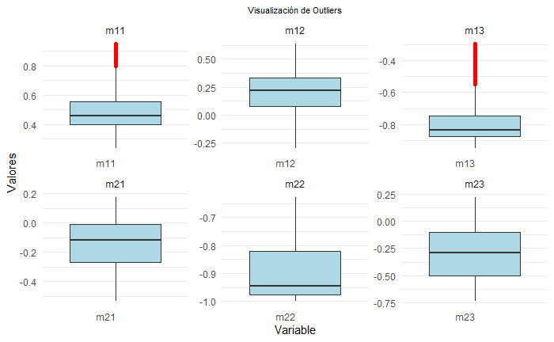

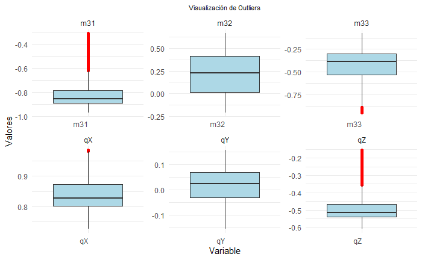

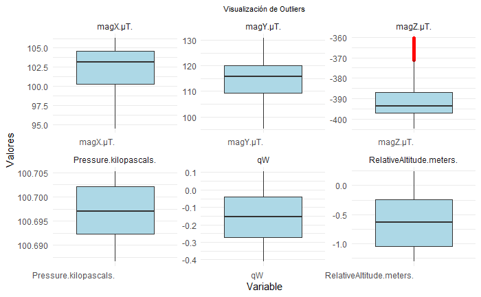

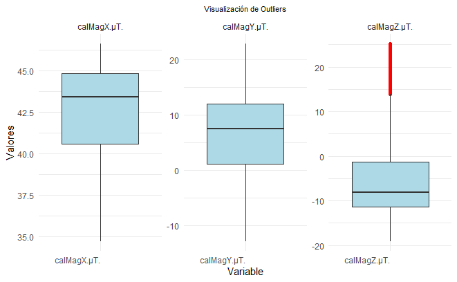

```r
if (ncol(num_data) > 0) {
  # Transformar datos a formato largo
  num_data_long <- num_data %>%
    pivot_longer(cols = everything(), names_to = "Variable", values_to = "Valor")

  # Dividir las variables en grupos de 6
  variable_groups <- split(unique(num_data_long$Variable), ceiling(seq_along(unique(num_data_long$Variable)) / 6))

  for (group in variable_groups) {
    # Filtrar las variables del grupo actual
    group_data_long <- num_data_long %>% filter(Variable %in% group)

    # Crear los boxplots
    print(
      ggplot(group_data_long, aes(x = Variable, y = Valor)) +
        geom_boxplot(outlier.colour = "red", outlier.size = 1.5, fill = "lightblue") +
        theme_minimal() +
        labs(
          title = "Visualización de Outliers",
          x = "Variable",
          y = "Valores"
        ) +
        theme(
          plot.title = element_text(size = 8, hjust = 0.5),
          axis.text.x = element_text(angle = 0, hjust = 1)
        ) +
        facet_wrap(~ Variable, scales = "free", ncol = 3)  # Cambia "ncol" a 2 o 3 según el diseño que prefieras
    )
  }
} else {
  cat("No hay variables numéricas en el dataset.\n")
}
```

En el análisis univariado, se identificaron variables con un porcentaje significativo de **outliers (>10%)**, lo que puede influir considerablemente en los análisis y resultados si no se manejan adecuadamente. Las variables más relevantes son:

1. **Yaw.rads. (22.95%)**: Representa la orientación angular del sistema. Los valores extremos podrían estar relacionados con cambios abruptos en la trayectoria o errores en los sensores. Se recomienda explorar estrategias como **winsorización** o **transformaciones robustas** para mitigar su impacto.
2. **gyroZ.rad.s. (14.57%) y gyroY.rad.s. (13.87%)**: Estas variables capturan las velocidades angulares en los ejes Z e Y, respectivamente. Los valores atípicos podrían ser el resultado de maniobras bruscas o ruido en los sensores. Es recomendable aplicar **winsorización** para suavizar su efecto.
3. **qZ (12.46%)**: Este componente de orientación podría estar influenciado por errores de calibración o cambios significativos en la dinámica del sistema. Se sugiere una **transformación** para manejar los outliers.
4. **accelUserX.g. (10.12%)**: Representa la aceleración específica en el eje X. Los valores extremos pueden estar asociados a vibraciones o turbulencias durante el despegue. Una **transformación ,** imputacion como winsorinzacion o mediana puede ayudar a estabilizar la distribución.

Estas variables son esenciales para comprender el sistema de transporte, incluyendo aspectos como posición, estabilidad, y precisión de los sensores. La aplicación de transformaciones adecuadas garantizará una mejor calidad de los datos y robustez en el análisis.

## 4.3 Multivariate Outliers

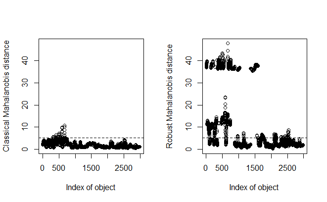

```r
# Cargar la librería
library(chemometrics)

# Crear una copia del dataset original para trabajar
data_analysis <- data

# Seleccionar las variables continuas con mayor porcentaje de outliers (>10%), excluyendo las mencionadas
selected_vars <- data_analysis %>%
  select(gyroZ.rad.s., gyroY.rad.s., Yaw.rads., qZ, accelUserX.g.)  # Incluir variables relevantes

# Calcular las distancias de Mahalanobis (clásica y robusta)
res.out <- Moutlier(selected_vars, quantile = 0.9999)
```

```r
# Inspeccionar resultados
str(res.out)
```

```
List of 3
 $ md    : num [1:2985] 1.99 2.21 2.41 2.48 2.47 ...
 $ rd    : num [1:2985] 37 37 37.1 37.1 37.1 ...
 $ cutoff: num 5.07
```

```r
# Visualizar outliers multivariantes
par(mfrow = c(1, 1)) # Una sola ventana de gráfico
plot(res.out$md, res.out$rd,
     xlab = "Mahalanobis Clásica",
     ylab = "Mahalanobis Robusta",
     main = "Outliers Multivariantes con Distancias de Mahalanobis")
abline(h = res.out$cutoff, col = "red") # Umbral robusto
```

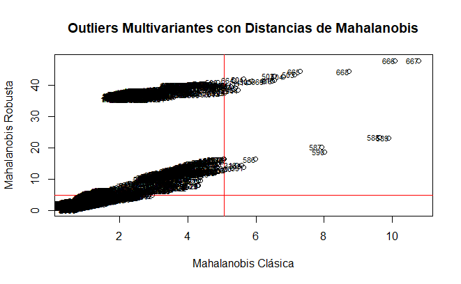

```r
abline(v = res.out$cutoff, col = "red") # Umbral clásico
text(res.out$md, res.out$rd, labels = rownames(data_analysis), adj = 1, cex = 0.7)
```

```r
# Identificar observaciones que son outliers multivariantes
outlier_indices <- which((res.out$md > res.out$cutoff) & (res.out$rd > res.out$cutoff))
cat("Observaciones outliers multivariantes:\n")
```

```
Observaciones outliers multivariantes:
```

```r
print(outlier_indices)
```

```
 [1] 318 319 320 404 405 414 415 416 417 501 502 503 504 505 544 545 546 547 586 587 588 589 590 591 633 664 665 666 667 668 669 703 704
```

```r
# Crear un nuevo dataset con la columna de outliers sin afectar el original
data_with_outliers <- data_analysis %>%
  mutate(outlier_multivar = ifelse(row_number() %in% outlier_indices, "Outlier", "No Outlier"))

# Resumen de la nueva variable en el dataset modificado
table(data_with_outliers$outlier_multivar)
```

```
No Outlier    Outlier
      2952         33
```

Para visualizar estos outliers, se generó un gráfico bivariado que muestra las distancias clásicas frente a las robustas. Los puntos fuera de las líneas rojas en el gráfico representan las observaciones más atípicas, las cuales merecen un análisis más detallado.

```r
# Mostrar un resumen de las filas marcadas como outliers
summary(data_with_outliers %>% filter(outlier_multivar == "Outlier"))
```

```
   Timestamp                        accelX.g.        accelY.g.         accelZ.g.      accelUserX.g.     accelUserY.g.     accelUserZ.g.      gyroX.rad.s.      gyroY.rad.s.     gyroZ.rad.s.
 Min.   :2020-09-11 23:12:16.06   Min.   :0.3224   Min.   :-0.2539   Min.   :0.5076   Min.   :-0.3179   Min.   :-0.0911   Min.   :-0.2804   Min.   :-1.1916   Min.   :-3.617   Min.   :-3.769
 1st Qu.:2020-09-11 23:12:17.05   1st Qu.:1.2001   1st Qu.:-0.0886   1st Qu.:0.6667   1st Qu.: 0.4783   1st Qu.:-0.0121   1st Qu.: 0.0764   1st Qu.: 0.0442   1st Qu.:-2.354   1st Qu.:-2.623
 Median :2020-09-11 23:12:18.35   Median :1.3614   Median : 0.2311   Median :0.7511   Median : 0.5691   Median : 0.1368   Median : 0.1703   Median : 0.4815   Median :-1.847   Median :-2.044
 Mean   :2020-09-11 23:12:18.25   Mean   :1.3776   Mean   : 0.1509   Mean   :0.7400   Mean   : 0.5769   Mean   : 0.1294   Mean   : 0.1331   Mean   : 0.2897   Mean   :-1.260   Mean   :-1.424
 3rd Qu.:2020-09-11 23:12:19.26   3rd Qu.:1.5246   3rd Qu.: 0.2681   3rd Qu.:0.8244   3rd Qu.: 0.7321   3rd Qu.: 0.2211   3rd Qu.: 0.2271   3rd Qu.: 0.7337   3rd Qu.:-1.296   3rd Qu.:-1.024
 Max.   :2020-09-11 23:12:19.94   Max.   :2.0890   Max.   : 0.3823   Max.   :0.9290   Max.   : 1.2430   Max.   : 0.3487   Max.   : 0.3870   Max.   : 0.9807   Max.   : 3.316   Max.   : 2.261
   Roll.rads.     Pitch.rads.        Yaw.rads.           m11              m12                m13               m21                m22               m23                m31
 Min.   :2.052   Min.   :-0.1508   Min.   :-3.138   Min.   :0.4566   Min.   :-0.22210   Min.   :-0.8837   Min.   :-0.12310   Min.   :-0.9996   Min.   :-0.15020   Min.   :-0.8867
 1st Qu.:2.142   1st Qu.:-0.0733   1st Qu.:-3.084   1st Qu.:0.5398   1st Qu.: 0.00650   1st Qu.:-0.8408   1st Qu.:-0.00460   1st Qu.:-0.9980   1st Qu.:-0.07320   1st Qu.:-0.8412
 Median :2.177   Median :-0.0275   Median :-3.054   Median :0.5698   Median : 0.04380   Median :-0.8204   Median : 0.04290   Median :-0.9954   Median :-0.02750   Median :-0.8218
 Mean   :2.221   Mean   :-0.0144   Mean   :-1.200   Mean   :0.5980   Mean   : 0.03802   Mean   :-0.7877   Mean   : 0.03739   Mean   :-0.9948   Mean   :-0.01441   Mean   :-0.7889
 3rd Qu.:2.249   3rd Qu.: 0.0469   3rd Qu.: 3.102   3rd Qu.:0.6279   3rd Qu.: 0.08060   3rd Qu.:-0.7783   3rd Qu.: 0.07800   3rd Qu.:-0.9942   3rd Qu.: 0.04690   3rd Qu.:-0.7772
 Max.   :2.549   Max.   : 0.2139   Max.   : 3.140   Max.   :0.8077   Max.   : 0.12710   Max.   :-0.5462   Max.   : 0.10910   Max.   :-0.9694   Max.   : 0.21230   Max.   :-0.5766
      m32                m33                qX               qY                 qZ                qW             ActivityType ActivityConfidence Pressure.kilopascals. RelativeAltitude.meters.
 Min.   :-0.11710   Min.   :-0.8103   Min.   :0.8533   Min.   :-0.09110   Min.   :-0.5187   Min.   :-0.068200   Cycling:33    High: 0            Min.   :100.7         Min.   :-0.5443
 1st Qu.:-0.08670   1st Qu.:-0.6273   1st Qu.:0.8763   1st Qu.: 0.00850   1st Qu.:-0.4793   1st Qu.:-0.021000                 Med :33            1st Qu.:100.7         1st Qu.:-0.3541
 Median :-0.03710   Median :-0.5686   Median :0.8855   Median : 0.02370   Median :-0.4636   Median :-0.000500                                    Median :100.7         Median :-0.2378
 Mean   :-0.02756   Mean   :-0.5980   Mean   :0.8928   Mean   : 0.02156   Mean   :-0.4431   Mean   : 0.002964                                    Mean   :100.7         Mean   :-0.1524
 3rd Qu.: 0.03050   3rd Qu.:-0.5379   3rd Qu.:0.9019   3rd Qu.: 0.03660   3rd Qu.:-0.4312   3rd Qu.: 0.033200                                    3rd Qu.:100.7         3rd Qu.: 0.2405
 Max.   : 0.08900   Max.   :-0.4615   Max.   :0.9487   Max.   : 0.06760   Max.   :-0.2964   Max.   : 0.083500                                    Max.   :100.7         Max.   : 0.2405
    magX.µT.        magY.µT.         magZ.µT.       calMagX.µT.     calMagY.µT.        calMagZ.µT.      outlier_multivar
 Min.   :101.7   Min.   : 96.74   Min.   :-388.8   Min.   :41.81   Min.   :-11.2121   Min.   :-5.1432   Length:33
 1st Qu.:105.0   1st Qu.:106.05   1st Qu.:-384.5   1st Qu.:45.40   1st Qu.:  0.0855   1st Qu.:-0.8569   Class :character
 Median :105.4   Median :109.41   Median :-383.6   Median :45.53   Median :  0.9544   Median : 0.8378   Mode  :character
 Mean   :105.1   Mean   :108.12   Mean   :-382.0   Mean   :45.41   Mean   :  0.9991   Mean   : 2.6230
 3rd Qu.:105.5   3rd Qu.:109.71   3rd Qu.:-379.8   3rd Qu.:46.01   3rd Qu.:  2.4480   3rd Qu.: 3.3369
 Max.   :106.1   Max.   :113.14   Max.   :-370.0   Max.   :46.19   Max.   :  5.6323   Max.   :14.9472
```

En este análisis, se utilizaron las distancias de Mahalanobis, tanto clásicas como robustas, para identificar outliers multivariantes en las variables clave: `gyroZ.rad.s.`, `gyroY.rad.s.`, `Yaw.rads.`, `qZ`, y `accelUserX.g.`. Estas variables fueron seleccionadas por su relevancia en el análisis del comportamiento dinámico del sistema y por presentar un alto porcentaje de outliers en el análisis univariado.

Los resultados identificaron **33 observaciones** (1.1% del total de registros) como outliers multivariantes. Estas sobresalen en el espacio multivariante, indicando eventos extremos o posibles anomalías asociadas a movimientos inusuales, errores de captura o condiciones específicas del entorno.

Se recomienda aplicar técnicas como **winsorización** para mitigar el impacto de estos valores extremos sin excluirlos, preservando su información potencialmente valiosa. Además, se sugiere un **análisis manual complementario** para identificar patrones o detalles que puedan escaparse del criterio automatizado de Mahalanobis y garantizar una comprensión más completa de las anomalías detectadas.

### Revision Manual

```r
# 1. Definir los índices de los outliers multivariantes (actualizados tras revisión manual)
outlier_indices <- c(
  318, 319, 320, 404, 405, 414, 415, 416, 417,
  501, 502, 503, 504, 505, 544, 545, 546, 547,
  586, 587, 588, 589, 590, 591, 633,
  664, 665, 666, 667, 668, 669, 703, 704
)

# 2. Filtrar las observaciones outliers del dataset original
outlier_data <- data_analysis[outlier_indices, ]
View(outlier_data)  # Abrir la vista interactiva para inspección

# 3. Resumen estadístico de los outliers
summary(outlier_data)
```

[output not shown]

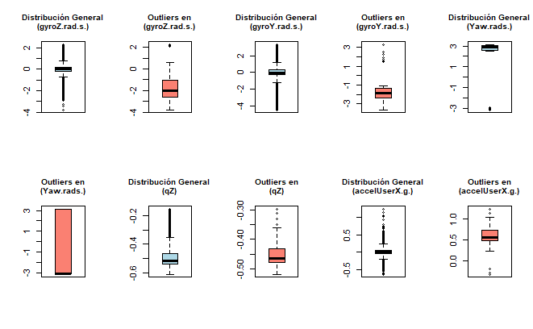

```r
# 4. Comparar distribuciones con el resto del dataset
# Configurar el layout para mostrar 5 pares de gráficos
par(mfrow = c(2, 5))  # 2 filas, 5 columnas

# Ajustar tamaño de título a 12
cex_title <- 0.9  # Factor de ajuste para el tamaño del título

# Variables del estudio
variables_estudio <- c("gyroZ.rad.s.", "gyroY.rad.s.", "Yaw.rads.", "qZ", "accelUserX.g.")

# Bucle para generar gráficos para cada variable
for (var in variables_estudio) {
  # Comparar distribución general
  boxplot(data_analysis[[var]],
          main = paste("Distribución General\n(", var, ")", sep = ""),
          col = "lightblue",
          cex.main = cex_title)

  # Comparar distribución de outliers
  boxplot(outlier_data[[var]],
          main = paste("Outliers en\n(", var, ")", sep = ""),
          col = "salmon",
          cex.main = cex_title)
}

# Resetear el layout
par(mfrow = c(1, 1))
```

```r
# 5. Inspeccionar registros adicionales
head(outlier_data[, c("Timestamp", "ActivityType", "gyroZ.rad.s.", "gyroY.rad.s.")])
```

|  | Timestamp | ActivityType | gyroZ.rad.s. | gyroY.rad.s. |
| --- | --- | --- | --- | --- |
| 318 | 2020-09-11 23:12:16 | Cycling | -2.2137 | -1.5186 |
| 319 | 2020-09-11 23:12:16 | Cycling | -2.1236 | -1.2961 |
| 320 | 2020-09-11 23:12:16 | Cycling | -1.9718 | -1.0787 |
| 404 | 2020-09-11 23:12:16 | Cycling | -0.9801 | -3.4680 |
| 405 | 2020-09-11 23:12:16 | Cycling | -1.0238 | -3.6166 |
| 414 | 2020-09-11 23:12:17 | Cycling | -2.0156 | -1.9270 |

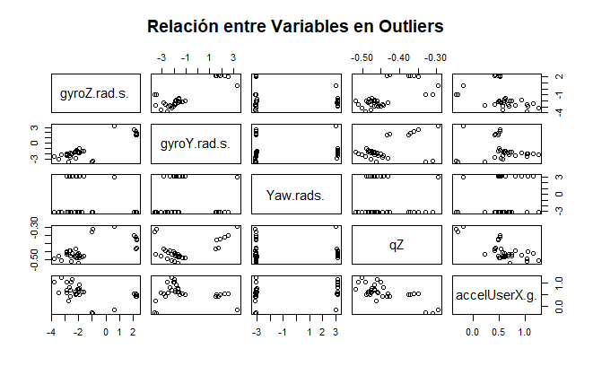

```r
# 6. Relación entre variables seleccionadas en los outliers
pairs(outlier_data[, c("gyroZ.rad.s.", "gyroY.rad.s.", "Yaw.rads.", "qZ", "accelUserX.g.")],
      main = "Relación entre Variables en Outliers")
```

```r
# 7. Agregar una columna de decisión manual para cada outlier
outlier_data <- outlier_data %>%
  mutate(decision = ifelse(gyroZ.rad.s. > 15 & gyroY.rad.s. > 15, "Conservar", "Revisar"))

# Mostrar dataset con decisiones
View(outlier_data)

# 8. Incorporar las decisiones al dataset original
data_analysis$outlier_review <- "No Outlier"
data_analysis$outlier_review[outlier_indices] <- outlier_data$decision

# 9. Resumen de las decisiones tomadas
table(data_analysis$outlier_review)
```

```
No Outlier    Revisar
      2952         33
```

### Validación Manual de Outliers Multivariantes

Como parte del análisis, se identificaron 33 observaciones clasificadas como outliers multivariantes utilizando distancias de Mahalanobis. Estas observaciones fueron revisadas manualmente para evaluar su posible origen y validez en el contexto de la actividad “Cycling”.

#### **Observaciones de la Validación Manual**

**Conclusión de la Validación Manual**

- No se detectaron errores evidentes en el formato de los datos ni inconsistencias generales en los registros revisados.
- Los valores atípicos parecen reflejar eventos específicos durante la actividad “Cycling”, lo que podría aportar información relevante para identificar **patrones dinámicos** o **fases significativas** dentro de esta actividad.

**Próximos Pasos**

1. **Transformaciones de Datos:**
   - Aplicar **winsorización** o **transformaciones logarítmicas** a las variables afectadas para limitar el impacto de los valores extremos sin perder la estructura de los datos.
   - Alternativamente, considerar técnicas robustas como **Normalización Z-Robust**.
2. **Segmentación de la Actividad “Cycling”:**
   - Realizar un análisis detallado para identificar si los valores extremos reflejan subpatrones legítimos dentro de esta actividad.
3. **Preparación para el Modelado:**
   - Escalar las variables seleccionadas tras la transformación para uniformar las magnitudes y reducir la influencia de los valores extremos en el entrenamiento del modelo.

# 5. Pruebas de Normalidad

Evaluar si las variables numéricas siguen una distribución normal es un paso clave para seleccionar las técnicas estadísticas y de modelado más adecuadas. Esto permite asegurar que los supuestos subyacentes de ciertos métodos estadísticos, como pruebas paramétricas o modelos lineales, se cumplan correctamente.

**Hipótesis:**

- **Nula (H₀):** Los datos tienen una distribución normal.
- **Alternativa (H₁):** Los datos no tienen una distribución normal.

Se utilizarán pruebas estadísticas, como **Shapiro-Wilk** o **Kolmogorov-Smirnov**, para contrastar estas hipótesis y determinar si los datos pueden considerarse normalmente distribuidos.

```r
summary(num_data)
```

```
   accelX.g.         accelY.g.         accelZ.g.       accelUserX.g.      accelUserY.g.       accelUserZ.g.       gyroX.rad.s.       gyroY.rad.s.       gyroZ.rad.s.        Roll.rads.
 Min.   :-0.1799   Min.   :-0.3039   Min.   :-0.2683   Min.   :-0.63060   Min.   :-0.292600   Min.   :-0.63610   Min.   :-1.79330   Min.   :-4.39540   Min.   :-3.76950   Min.   :1.665
 1st Qu.: 0.7355   1st Qu.: 0.0723   1st Qu.: 0.2678   1st Qu.:-0.04360   1st Qu.:-0.056700   1st Qu.:-0.07290   1st Qu.:-0.30380   1st Qu.:-0.28280   1st Qu.:-0.17660   1st Qu.:1.900
 Median : 0.8477   Median : 0.2906   Median : 0.3781   Median : 0.00580   Median :-0.008800   Median :-0.00870   Median :-0.00020   Median :-0.00350   Median : 0.00280   Median :1.998
 Mean   : 0.8027   Mean   : 0.2699   Mean   : 0.4064   Mean   : 0.01387   Mean   : 0.003483   Mean   :-0.01992   Mean   :-0.02185   Mean   :-0.01767   Mean   :-0.00224   Mean   :2.057
 3rd Qu.: 0.9175   3rd Qu.: 0.4778   3rd Qu.: 0.5598   3rd Qu.: 0.06600   3rd Qu.: 0.050800   3rd Qu.: 0.04420   3rd Qu.: 0.28110   3rd Qu.: 0.31090   3rd Qu.: 0.20400   3rd Qu.:2.141
 Max.   : 2.0890   Max.   : 1.0647   Max.   : 0.9785   Max.   : 1.24300   Max.   : 0.434900   Max.   : 0.60770   Max.   : 1.65650   Max.   : 3.31610   Max.   : 2.28740   Max.   :2.836
  Pitch.rads.        Yaw.rads.           m11              m12               m13               m21               m22               m23               m31               m32
 Min.   :-0.8318   Min.   :-3.142   Min.   :0.2404   Min.   :-0.2943   Min.   :-0.9478   Min.   :-0.5359   Min.   :-0.9999   Min.   :-0.7391   Min.   :-0.9698   Min.   :-0.2094
 1st Qu.:-0.5265   1st Qu.: 2.582   1st Qu.:0.3974   1st Qu.: 0.0761   1st Qu.:-0.8758   1st Qu.:-0.2666   1st Qu.:-0.9773   1st Qu.:-0.5025   1st Qu.:-0.8939   1st Qu.: 0.0172
 Median :-0.2931   Median : 2.853   Median :0.4598   Median : 0.2156   Median :-0.8351   Median :-0.1172   Median :-0.9444   Median :-0.2889   Median :-0.8540   Median : 0.2240
 Mean   :-0.2789   Mean   : 1.538   Mean   :0.5043   Mean   : 0.1961   Mean   :-0.7887   Mean   :-0.1380   Mean   :-0.9004   Mean   :-0.2661   Mean   :-0.8112   Mean   : 0.2167
 3rd Qu.:-0.1033   3rd Qu.: 3.031   3rd Qu.:0.5571   3rd Qu.: 0.3340   3rd Qu.:-0.7462   3rd Qu.:-0.0126   3rd Qu.:-0.8219   3rd Qu.:-0.1031   3rd Qu.:-0.7850   3rd Qu.: 0.4107
 Max.   : 0.2206   Max.   : 3.142   Max.   :0.9478   Max.   : 0.6333   Max.   :-0.2981   Max.   : 0.1723   Max.   :-0.6293   Max.   : 0.2188   Max.   :-0.3093   Max.   : 0.6642
      m33                qX               qY                qZ                qW          Pressure.kilopascals. RelativeAltitude.meters.    magX.µT.         magY.µT.         magZ.µT.
 Min.   :-0.9465   Min.   :0.7256   Min.   :-0.1563   Min.   :-0.6111   Min.   :-0.4122   Min.   :100.7         Min.   :-1.3159          Min.   : 94.49   Min.   : 95.44   Min.   :-404.6
 1st Qu.:-0.5334   1st Qu.:0.8008   1st Qu.:-0.0303   1st Qu.:-0.5413   1st Qu.:-0.2727   1st Qu.:100.7         1st Qu.:-1.0543          1st Qu.:100.28   1st Qu.:109.30   1st Qu.:-397.1
 Median :-0.3850   Median :0.8280   Median : 0.0239   Median :-0.5145   Median :-0.1552   Median :100.7         Median :-0.6289          Median :103.15   Median :115.67   Median :-393.8
 Mean   :-0.4264   Mean   :0.8390   Mean   : 0.0194   Mean   :-0.4830   Mean   :-0.1537   Mean   :100.7         Mean   :-0.6291          Mean   :102.44   Mean   :114.55   Mean   :-390.5
 3rd Qu.:-0.2979   3rd Qu.:0.8730   3rd Qu.: 0.0695   3rd Qu.:-0.4671   3rd Qu.:-0.0417   3rd Qu.:100.7         3rd Qu.:-0.2378          3rd Qu.:104.60   3rd Qu.:120.04   3rd Qu.:-386.8
 Max.   :-0.0776   Max.   :0.9854   Max.   : 0.1566   Max.   :-0.1542   Max.   : 0.1049   Max.   :100.7         Max.   : 0.2405          Max.   :106.26   Max.   :130.76   Max.   :-360.5
  calMagX.µT.     calMagY.µT.       calMagZ.µT.
 Min.   :34.70   Min.   :-12.877   Min.   :-19.062
 1st Qu.:40.59   1st Qu.:  1.127   1st Qu.:-11.339
 Median :43.43   Median :  7.513   Median : -8.062
 Mean   :42.70   Mean   :  6.529   Mean   : -4.793
 3rd Qu.:44.82   3rd Qu.: 12.016   3rd Qu.: -1.241
 Max.   :46.63   Max.   : 22.848   Max.   : 25.217
```

```r
summary(num_data)
```

```
   accelX.g.         accelY.g.         accelZ.g.       accelUserX.g.      accelUserY.g.       accelUserZ.g.       gyroX.rad.s.       gyroY.rad.s.       gyroZ.rad.s.        Roll.rads.
 Min.   :-0.1799   Min.   :-0.3039   Min.   :-0.2683   Min.   :-0.63060   Min.   :-0.292600   Min.   :-0.63610   Min.   :-1.79330   Min.   :-4.39540   Min.   :-3.76950   Min.   :1.665
 1st Qu.: 0.7355   1st Qu.: 0.0723   1st Qu.: 0.2678   1st Qu.:-0.04360   1st Qu.:-0.056700   1st Qu.:-0.07290   1st Qu.:-0.30380   1st Qu.:-0.28280   1st Qu.:-0.17660   1st Qu.:1.900
 Median : 0.8477   Median : 0.2906   Median : 0.3781   Median : 0.00580   Median :-0.008800   Median :-0.00870   Median :-0.00020   Median :-0.00350   Median : 0.00280   Median :1.998
 Mean   : 0.8027   Mean   : 0.2699   Mean   : 0.4064   Mean   : 0.01387   Mean   : 0.003483   Mean   :-0.01992   Mean   :-0.02185   Mean   :-0.01767   Mean   :-0.00224   Mean   :2.057
 3rd Qu.: 0.9175   3rd Qu.: 0.4778   3rd Qu.: 0.5598   3rd Qu.: 0.06600   3rd Qu.: 0.050800   3rd Qu.: 0.04420   3rd Qu.: 0.28110   3rd Qu.: 0.31090   3rd Qu.: 0.20400   3rd Qu.:2.141
 Max.   : 2.0890   Max.   : 1.0647   Max.   : 0.9785   Max.   : 1.24300   Max.   : 0.434900   Max.   : 0.60770   Max.   : 1.65650   Max.   : 3.31610   Max.   : 2.28740   Max.   :2.836
  Pitch.rads.        Yaw.rads.           m11              m12               m13               m21               m22               m23               m31               m32
 Min.   :-0.8318   Min.   :-3.142   Min.   :0.2404   Min.   :-0.2943   Min.   :-0.9478   Min.   :-0.5359   Min.   :-0.9999   Min.   :-0.7391   Min.   :-0.9698   Min.   :-0.2094
 1st Qu.:-0.5265   1st Qu.: 2.582   1st Qu.:0.3974   1st Qu.: 0.0761   1st Qu.:-0.8758   1st Qu.:-0.2666   1st Qu.:-0.9773   1st Qu.:-0.5025   1st Qu.:-0.8939   1st Qu.: 0.0172
 Median :-0.2931   Median : 2.853   Median :0.4598   Median : 0.2156   Median :-0.8351   Median :-0.1172   Median :-0.9444   Median :-0.2889   Median :-0.8540   Median : 0.2240
 Mean   :-0.2789   Mean   : 1.538   Mean   :0.5043   Mean   : 0.1961   Mean   :-0.7887   Mean   :-0.1380   Mean   :-0.9004   Mean   :-0.2661   Mean   :-0.8112   Mean   : 0.2167
 3rd Qu.:-0.1033   3rd Qu.: 3.031   3rd Qu.:0.5571   3rd Qu.: 0.3340   3rd Qu.:-0.7462   3rd Qu.:-0.0126   3rd Qu.:-0.8219   3rd Qu.:-0.1031   3rd Qu.:-0.7850   3rd Qu.: 0.4107
 Max.   : 0.2206   Max.   : 3.142   Max.   :0.9478   Max.   : 0.6333   Max.   :-0.2981   Max.   : 0.1723   Max.   :-0.6293   Max.   : 0.2188   Max.   :-0.3093   Max.   : 0.6642
      m33                qX               qY                qZ                qW          Pressure.kilopascals. RelativeAltitude.meters.    magX.µT.         magY.µT.         magZ.µT.
 Min.   :-0.9465   Min.   :0.7256   Min.   :-0.1563   Min.   :-0.6111   Min.   :-0.4122   Min.   :100.7         Min.   :-1.3159          Min.   : 94.49   Min.   : 95.44   Min.   :-404.6
 1st Qu.:-0.5334   1st Qu.:0.8008   1st Qu.:-0.0303   1st Qu.:-0.5413   1st Qu.:-0.2727   1st Qu.:100.7         1st Qu.:-1.0543          1st Qu.:100.28   1st Qu.:109.30   1st Qu.:-397.1
 Median :-0.3850   Median :0.8280   Median : 0.0239   Median :-0.5145   Median :-0.1552   Median :100.7         Median :-0.6289          Median :103.15   Median :115.67   Median :-393.8
 Mean   :-0.4264   Mean   :0.8390   Mean   : 0.0194   Mean   :-0.4830   Mean   :-0.1537   Mean   :100.7         Mean   :-0.6291          Mean   :102.44   Mean   :114.55   Mean   :-390.5
 3rd Qu.:-0.2979   3rd Qu.:0.8730   3rd Qu.: 0.0695   3rd Qu.:-0.4671   3rd Qu.:-0.0417   3rd Qu.:100.7         3rd Qu.:-0.2378          3rd Qu.:104.60   3rd Qu.:120.04   3rd Qu.:-386.8
 Max.   :-0.0776   Max.   :0.9854   Max.   : 0.1566   Max.   :-0.1542   Max.   : 0.1049   Max.   :100.7         Max.   : 0.2405          Max.   :106.26   Max.   :130.76   Max.   :-360.5
  calMagX.µT.     calMagY.µT.       calMagZ.µT.
 Min.   :34.70   Min.   :-12.877   Min.   :-19.062
 1st Qu.:40.59   1st Qu.:  1.127   1st Qu.:-11.339
 Median :43.43   Median :  7.513   Median : -8.062
 Mean   :42.70   Mean   :  6.529   Mean   : -4.793
 3rd Qu.:44.82   3rd Qu.: 12.016   3rd Qu.: -1.241
 Max.   :46.63   Max.   : 22.848   Max.   : 25.217
```

# **6. Análisis de Asimetría, Curtosis y Varianza**

Este análisis ayuda a identificar variables con distribuciones sesgadas, colas largas o alta variabilidad. Esto es útil para detectar patrones y posibles transformaciones.

```r
if (ncol(num_data) > 0) {
  cat("### Análisis de Asimetría, Curtosis y Varianza")

  # Calcular asimetría, curtosis y varianza
  skew_kurt_var <- num_data %>%
    summarise(across(everything(), list(
      skewness = ~ skewness(.x, na.rm = TRUE),
      kurtosis = ~ kurtosis(.x, na.rm = TRUE),
      variance = ~ var(.x, na.rm = TRUE)
    )))

  # Convertir resultados a formato largo
  skew_kurt_var_long <- skew_kurt_var %>%
    pivot_longer(cols = everything(), names_to = c("Variable", "Metric"), names_sep = "_") %>%
    pivot_wider(names_from = "Metric", values_from = "value")

  # Renombrar las columnas para mayor claridad
  colnames(skew_kurt_var_long) <- c("Variable", "Asimetría (Skewness)", "Curtosis (Kurtosis)", "Varianza")

  # Mostrar la tabla
  print(skew_kurt_var_long)
} else {
  cat("No hay variables numéricas en el dataset.\n")
}
```

```
### Análisis de Asimetría, Curtosis y Varianza
```

| Variable | Asimetría (Skewness) | Curtosis (Kurtosis) | Varianza |
| --- | --- | --- | --- |
| accelX.g. | -1.14289814 | 7.473694 | 5.011362e-02 |
| accelY.g. | -0.17624467 | 2.298606 | 7.208752e-02 |
| accelZ.g. | 0.15458720 | 2.544633 | 4.138494e-02 |
| accelUserX.g. | 1.07683610 | 12.526479 | 2.015732e-02 |
| accelUserY.g. | 0.72016234 | 4.137221 | 8.967847e-03 |
| accelUserZ.g. | -0.51998465 | 5.685268 | 1.786099e-02 |
| gyroX.rad.s. | -0.27098187 | 3.573249 | 2.396805e-01 |
| gyroY.rad.s. | -0.56999282 | 7.204066 | 9.193963e-01 |
| gyroZ.rad.s. | -0.45527962 | 7.470727 | 3.812430e-01 |
| Roll.rads. | 1.07436768 | 3.724869 | 6.780126e-02 |

[output cut: 23 more lines]

Dado que las variables no siguen una distribución normal y algunas contienen valores extremos, se recomienda utilizar **RobustScaler** para manejar variables con alta asimetría y curtosis, ya que es resistente a los outliers. Alternativamente, **Min-Max Scaling** puede ser útil para algoritmos sensibles a escalas absolutas, especialmente después de aplicar técnicas como winsorización o transformaciones logarítmicas para suavizar los valores extremos. Este enfoque garantiza una preparación óptima de los datos para análisis predictivos y modelos.

# **7**. Análisis de Correlaciones

Las correlaciones entre variables numéricas son esenciales para identificar redundancias o relaciones útiles para el modelado.

```r
library(knitr)      # Para formatear tablas
library(kableExtra) # Para mejorar la presentación

# Verificar si hay variables numéricas
if (ncol(num_data) > 0) {
  # Filtrar dinámicamente las variables numéricas (descartando automáticamente no numéricas)
  num_data_filtered <- num_data %>%
    select(where(is.numeric))

  # Comprobar que hay más de una variable numérica para calcular correlación
  if (ncol(num_data_filtered) > 1) {
    # Calcular la matriz de correlación
    cor_matrix <- cor(num_data_filtered, use = "complete.obs")

    # Redondear para mejor visualización
    cor_matrix_rounded <- round(cor_matrix, 2)

    # Imprimir la matriz de correlación en la consola
    print("### Matriz de Correlación (Variables Numéricas)")
    print(cor_matrix_rounded)

    # Generar una tabla con knitr::kable para visualización más ordenada
    library(knitr)
    kable(cor_matrix_rounded, caption = "Tabla de Correlaciones (Solo Variables Numéricas)")
  } else {
    cat("No hay suficientes variables numéricas para calcular una matriz de correlación.\n")
  }
} else {
  cat("No hay variables numéricas en el dataset.\n")
}
```

```
[1] "### Matriz de Correlación (Variables Numéricas)"
                         accelX.g. accelY.g. accelZ.g. accelUserX.g. accelUserY.g. accelUserZ.g. gyroX.rad.s. gyroY.rad.s. gyroZ.rad.s. Roll.rads. Pitch.rads. Yaw.rads.   m11   m12   m13   m21
accelX.g.                     1.00      0.30     -0.06          0.83          0.03          0.68        -0.12         0.06        -0.07      -0.59       -0.28     -0.19 -0.64  0.32 -0.81  0.04
accelY.g.                     0.30      1.00     -0.72          0.07          0.36          0.26         0.04        -0.01        -0.11      -0.81       -0.93      0.31 -0.71  0.89 -0.44 -0.43
accelZ.g.                    -0.06     -0.72      1.00          0.24         -0.02          0.24        -0.09         0.07         0.07       0.74        0.77     -0.36  0.65 -0.70  0.37  0.56
accelUserX.g.                 0.83      0.07      0.24          1.00          0.02          0.59        -0.08         0.18         0.04      -0.20       -0.05     -0.24 -0.22  0.11 -0.36  0.18
accelUserY.g.                 0.03      0.36     -0.02          0.02          1.00          0.00         0.01        -0.02        -0.19      -0.02       -0.01      0.12 -0.05  0.00 -0.05 -0.02
accelUserZ.g.                 0.68      0.26      0.24          0.59          0.00          1.00        -0.21         0.12        -0.01      -0.45       -0.28     -0.17 -0.47  0.31 -0.53  0.02
gyroX.rad.s.                 -0.12      0.04     -0.09         -0.08          0.01         -0.21         1.00        -0.15        -0.42       0.08       -0.03      0.09  0.10  0.00  0.12 -0.04
gyroY.rad.s.                  0.06     -0.01      0.07          0.18         -0.02          0.12        -0.15         1.00         0.71       0.00       -0.01     -0.13 -0.01  0.06  0.01  0.09
gyroZ.rad.s.                 -0.07     -0.11      0.07          0.04         -0.19         -0.01        -0.42         0.71         1.00       0.09        0.03     -0.07  0.11 -0.02  0.12  0.01
Roll.rads.                   -0.59     -0.81      0.74         -0.20         -0.02         -0.45         0.08         0.00         0.09       1.00        0.85     -0.17  0.94 -0.81  0.79  0.46
Pitch.rads.                  -0.28     -0.93      0.77         -0.05         -0.01         -0.28        -0.03        -0.01         0.03       0.85        1.00     -0.30  0.73 -0.95  0.42  0.46
Yaw.rads.                    -0.19      0.31     -0.36         -0.24          0.12         -0.17         0.09        -0.13        -0.07      -0.17       -0.30      1.00 -0.06  0.09  0.07 -0.65
m11                          -0.64     -0.71      0.65         -0.22         -0.05         -0.47         0.10        -0.01         0.11       0.94        0.73     -0.06  1.00 -0.74  0.87  0.25
m12                           0.32      0.89     -0.70          0.11          0.00          0.31         0.00         0.06        -0.02      -0.81       -0.95      0.09 -0.74  1.00 -0.43 -0.20
m13                          -0.81     -0.44      0.37         -0.36         -0.05         -0.53         0.12         0.01         0.12       0.79        0.42      0.07  0.87 -0.43  1.00  0.13
m21                           0.04     -0.43      0.56          0.18         -0.02          0.02        -0.04         0.09         0.01       0.46        0.46     -0.65  0.25 -0.20  0.13  1.00
m22                           0.00      0.77     -0.72         -0.08         -0.03          0.11         0.04         0.00         0.01      -0.66       -0.85      0.37 -0.42  0.74 -0.09 -0.69
m23                          -0.30     -0.94      0.77         -0.06         -0.01         -0.29        -0.03        -0.02         0.03       0.86        1.00     -0.29  0.75 -0.95  0.45  0.46
m31                          -0.73     -0.61      0.46         -0.33         -0.06         -0.52         0.09        -0.01         0.13       0.84        0.62      0.05  0.93 -0.68  0.90 -0.01
m32                           0.24      0.79     -0.74         -0.01          0.01          0.20         0.03        -0.04        -0.02      -0.78       -0.84      0.53 -0.60  0.65 -0.42 -0.85
m33                           0.49      0.85     -0.79          0.14          0.02          0.39        -0.06         0.00        -0.07      -0.99       -0.90      0.23 -0.91  0.86 -0.69 -0.52
qX                           -0.45     -0.86      0.80         -0.11         -0.02         -0.37         0.06         0.00         0.07       0.98        0.91     -0.23  0.90 -0.87  0.66  0.52
qY                            0.27      0.48     -0.23          0.20         -0.01          0.26        -0.02         0.11        -0.01      -0.37       -0.51     -0.35 -0.46  0.73 -0.25  0.51
qZ                           -0.71     -0.70      0.61         -0.27         -0.05         -0.51         0.10         0.00         0.12       0.95        0.71     -0.05  0.99 -0.72  0.92  0.24
```

[output cut: 38 more lines]

Tabla de Correlaciones (Solo Variables Numéricas)

|  | accelX.g. | accelY.g. | accelZ.g. | accelUserX.g. | accelUserY.g. | accelUserZ.g. | gyroX.rad.s. | gyroY.rad.s. | gyroZ.rad.s. | Roll.rads. | Pitch.rads. | Yaw.rads. | m11 | m12 | m13 | m21 | m22 | m23 | m31 | m32 | m33 | qX | qY | qZ | qW | Pressure.kilopascals. | RelativeAltitude.meters. | magX.µT. | magY.µT. | … |
| --- | --- | --- | --- | --- | --- | --- | --- | --- | --- | --- | --- | --- | --- | --- | --- | --- | --- | --- | --- | --- | --- | --- | --- | --- | --- | --- | --- | --- | --- | --- |
| accelX.g. | 1.00 | 0.30 | -0.06 | 0.83 | 0.03 | 0.68 | -0.12 | 0.06 | -0.07 | -0.59 | -0.28 | -0.19 | -0.64 | 0.32 | -0.81 | 0.04 | 0.00 | -0.30 | -0.73 | 0.24 | 0.49 | -0.45 | 0.27 | -0.71 | -0.25 | -0.03 | 0.03 | 0.53 | 0.34 | … |
| accelY.g. | 0.30 | 1.00 | -0.72 | 0.07 | 0.36 | 0.26 | 0.04 | -0.01 | -0.11 | -0.81 | -0.93 | 0.31 | -0.71 | 0.89 | -0.44 | -0.43 | 0.77 | -0.94 | -0.61 | 0.79 | 0.85 | -0.86 | 0.48 | -0.70 | -0.90 | 0.23 | -0.23 | -0.35 | 0.82 | … |
| accelZ.g. | -0.06 | -0.72 | 1.00 | 0.24 | -0.02 | 0.24 | -0.09 | 0.07 | 0.07 | 0.74 | 0.77 | -0.36 | 0.65 | -0.70 | 0.37 | 0.56 | -0.72 | 0.77 | 0.46 | -0.74 | -0.79 | 0.80 | -0.23 | 0.61 | 0.80 | -0.25 | 0.25 | 0.37 | -0.58 | … |
| accelUserX.g. | 0.83 | 0.07 | 0.24 | 1.00 | 0.02 | 0.59 | -0.08 | 0.18 | 0.04 | -0.20 | -0.05 | -0.24 | -0.22 | 0.11 | -0.36 | 0.18 | -0.08 | -0.06 | -0.33 | -0.01 | 0.14 | -0.11 | 0.20 | -0.27 | -0.01 | -0.04 | 0.04 | 0.37 | 0.16 | … |
| accelUserY.g. | 0.03 | 0.36 | -0.02 | 0.02 | 1.00 | 0.00 | 0.01 | -0.02 | -0.19 | -0.02 | -0.01 | 0.12 | -0.05 | 0.00 | -0.05 | -0.02 | -0.03 | -0.01 | -0.06 | 0.01 | 0.02 | -0.02 | -0.01 | -0.05 | -0.01 | -0.20 | 0.20 | 0.02 | -0.02 | … |
| accelUserZ.g. | 0.68 | 0.26 | 0.24 | 0.59 | 0.00 | 1.00 | -0.21 | 0.12 | -0.01 | -0.45 | -0.28 | -0.17 | -0.47 | 0.31 | -0.53 | 0.02 | 0.11 | -0.29 | -0.52 | 0.20 | 0.39 | -0.37 | 0.26 | -0.51 | -0.24 | 0.11 | -0.11 | 0.28 | 0.32 | … |
| gyroX.rad.s. | -0.12 | 0.04 | -0.09 | -0.08 | 0.01 | -0.21 | 1.00 | -0.15 | -0.42 | 0.08 | -0.03 | 0.09 | 0.10 | 0.00 | 0.12 | -0.04 | 0.04 | -0.03 | 0.09 | 0.03 | -0.06 | 0.06 | -0.02 | 0.10 | -0.03 | 0.07 | -0.07 | -0.06 | -0.02 | … |
| gyroY.rad.s. | 0.06 | -0.01 | 0.07 | 0.18 | -0.02 | 0.12 | -0.15 | 1.00 | 0.71 | 0.00 | -0.01 | -0.13 | -0.01 | 0.06 | 0.01 | 0.09 | 0.00 | -0.02 | -0.01 | -0.04 | 0.00 | 0.00 | 0.11 | 0.00 | 0.01 | -0.03 | 0.03 | 0.06 | 0.12 | … |
| gyroZ.rad.s. | -0.07 | -0.11 | 0.07 | 0.04 | -0.19 | -0.01 | -0.42 | 0.71 | 1.00 | 0.09 | 0.03 | -0.07 | 0.11 | -0.02 | 0.12 | 0.01 | 0.01 | 0.03 | 0.13 | -0.02 | -0.07 | 0.07 | -0.01 | 0.12 | 0.02 | -0.04 | 0.04 | -0.02 | 0.05 | … |
| Roll.rads. | -0.59 | -0.81 | 0.74 | -0.20 | -0.02 | -0.45 | 0.08 | 0.00 | 0.09 | 1.00 | 0.85 | -0.17 | 0.94 | -0.81 | 0.79 | 0.46 | -0.66 | 0.86 | 0.84 | -0.78 | -0.99 | 0.98 | -0.37 | 0.95 | 0.85 | -0.27 | 0.27 | 0.05 | -0.71 | … |
| Pitch.rads. | -0.28 | -0.93 | 0.77 | -0.05 | -0.01 | -0.28 | -0.03 | -0.01 | 0.03 | 0.85 | 1.00 | -0.30 | 0.73 | -0.95 | 0.42 | 0.46 | -0.85 | 1.00 | 0.62 | -0.84 | -0.90 | 0.91 | -0.51 | 0.71 | 0.96 | -0.33 | 0.33 | 0.41 | -0.88 | … |
| Yaw.rads. | -0.19 | 0.31 | -0.36 | -0.24 | 0.12 | -0.17 | 0.09 | -0.13 | -0.07 | -0.17 | -0.30 | 1.00 | -0.06 | 0.09 | 0.07 | -0.65 | 0.37 | -0.29 | 0.05 | 0.53 | 0.23 | -0.23 | -0.35 | -0.05 | -0.42 | 0.27 | -0.27 | -0.23 | -0.01 | … |
| m11 | -0.64 | -0.71 | 0.65 | -0.22 | -0.05 | -0.47 | 0.10 | -0.01 | 0.11 | 0.94 | 0.73 | -0.06 | 1.00 | -0.74 | 0.87 | 0.25 | -0.42 | 0.75 | 0.93 | -0.60 | -0.91 | 0.90 | -0.46 | 0.99 | 0.68 | -0.10 | 0.10 | -0.05 | -0.69 | … |
| m12 | 0.32 | 0.89 | -0.70 | 0.11 | 0.00 | 0.31 | 0.00 | 0.06 | -0.02 | -0.81 | -0.95 | 0.09 | -0.74 | 1.00 | -0.43 | -0.20 | 0.74 | -0.95 | -0.68 | 0.65 | 0.86 | -0.87 | 0.73 | -0.72 | -0.84 | 0.20 | -0.20 | -0.43 | 0.97 | … |
| m13 | -0.81 | -0.44 | 0.37 | -0.36 | -0.05 | -0.53 | 0.12 | 0.01 | 0.12 | 0.79 | 0.42 | 0.07 | 0.87 | -0.43 | 1.00 | 0.13 | -0.09 | 0.45 | 0.90 | -0.42 | -0.69 | 0.66 | -0.25 | 0.92 | 0.42 | 0.01 | -0.02 | -0.51 | -0.41 | … |
| m21 | 0.04 | -0.43 | 0.56 | 0.18 | -0.02 | 0.02 | -0.04 | 0.09 | 0.01 | 0.46 | 0.46 | -0.65 | 0.25 | -0.20 | 0.13 | 1.00 | -0.69 | 0.46 | -0.01 | -0.85 | -0.52 | 0.52 | 0.51 | 0.24 | 0.69 | -0.51 | 0.52 | 0.15 | 0.00 | … |
| m22 | 0.00 | 0.77 | -0.72 | -0.08 | -0.03 | 0.11 | 0.04 | 0.00 | 0.01 | -0.66 | -0.85 | 0.37 | -0.42 | 0.74 | -0.09 | -0.69 | 1.00 | -0.84 | -0.23 | 0.85 | 0.75 | -0.77 | 0.18 | -0.40 | -0.91 | 0.53 | -0.53 | -0.55 | 0.60 | … |
| m23 | -0.30 | -0.94 | 0.77 | -0.06 | -0.01 | -0.29 | -0.03 | -0.02 | 0.03 | 0.86 | 1.00 | -0.29 | 0.75 | -0.95 | 0.45 | 0.46 | -0.84 | 1.00 | 0.64 | -0.84 | -0.91 | 0.92 | -0.51 | 0.73 | 0.96 | -0.32 | 0.32 | 0.38 | -0.89 | … |
| m31 | -0.73 | -0.61 | 0.46 | -0.33 | -0.06 | -0.52 | 0.09 | -0.01 | 0.13 | 0.84 | 0.62 | 0.05 | 0.93 | -0.68 | 0.90 | -0.01 | -0.23 | 0.64 | 1.00 | -0.41 | -0.77 | 0.75 | -0.58 | 0.95 | 0.52 | 0.01 | -0.01 | -0.20 | -0.70 | … |
| m32 | 0.24 | 0.79 | -0.74 | -0.01 | 0.01 | 0.20 | 0.03 | -0.04 | -0.02 | -0.78 | -0.84 | 0.53 | -0.60 | 0.65 | -0.42 | -0.85 | 0.85 | -0.84 | -0.41 | 1.00 | 0.83 | -0.83 | -0.03 | -0.60 | -0.95 | 0.48 | -0.48 | -0.17 | 0.50 | … |
| m33 | 0.49 | 0.85 | -0.79 | 0.14 | 0.02 | 0.39 | -0.06 | 0.00 | -0.07 | -0.99 | -0.90 | 0.23 | -0.91 | 0.86 | -0.69 | -0.52 | 0.75 | -0.91 | -0.77 | 0.83 | 1.00 | -1.00 | 0.38 | -0.90 | -0.91 | 0.31 | -0.31 | -0.18 | 0.75 | … |
| qX | -0.45 | -0.86 | 0.80 | -0.11 | -0.02 | -0.37 | 0.06 | 0.00 | 0.07 | 0.98 | 0.91 | -0.23 | 0.90 | -0.87 | 0.66 | 0.52 | -0.77 | 0.92 | 0.75 | -0.83 | -1.00 | 1.00 | -0.39 | 0.88 | 0.91 | -0.32 | 0.32 | 0.23 | -0.75 | … |
| qY | 0.27 | 0.48 | -0.23 | 0.20 | -0.01 | 0.26 | -0.02 | 0.11 | -0.01 | -0.37 | -0.51 | -0.35 | -0.46 | 0.73 | -0.25 | 0.51 | 0.18 | -0.51 | -0.58 | -0.03 | 0.38 | -0.39 | 1.00 | -0.44 | -0.26 | -0.17 | 0.17 | -0.33 | 0.84 | … |
| qZ | -0.71 | -0.70 | 0.61 | -0.27 | -0.05 | -0.51 | 0.10 | 0.00 | 0.12 | 0.95 | 0.71 | -0.05 | 0.99 | -0.72 | 0.92 | 0.24 | -0.40 | 0.73 | 0.95 | -0.60 | -0.90 | 0.88 | -0.44 | 1.00 | 0.67 | -0.11 | 0.11 | -0.15 | -0.67 | … |
| qW | -0.25 | -0.90 | 0.80 | -0.01 | -0.01 | -0.24 | -0.03 | 0.01 | 0.02 | 0.85 | 0.96 | -0.42 | 0.68 | -0.84 | 0.42 | 0.69 | -0.91 | 0.96 | 0.52 | -0.95 | -0.91 | 0.91 | -0.26 | 0.67 | 1.00 | -0.43 | 0.43 | 0.34 | -0.72 | … |
| Pressure.kilopascals. | -0.03 | 0.23 | -0.25 | -0.04 | -0.20 | 0.11 | 0.07 | -0.03 | -0.04 | -0.27 | -0.33 | 0.27 | -0.10 | 0.20 | 0.01 | -0.51 | 0.53 | -0.32 | 0.01 | 0.48 | 0.31 | -0.32 | -0.17 | -0.11 | -0.43 | 1.00 | -1.00 | -0.18 | 0.10 | … |
| RelativeAltitude.meters. | 0.03 | -0.23 | 0.25 | 0.04 | 0.20 | -0.11 | -0.07 | 0.03 | 0.04 | 0.27 | 0.33 | -0.27 | 0.10 | -0.20 | -0.02 | 0.52 | -0.53 | 0.32 | -0.01 | -0.48 | -0.31 | 0.32 | 0.17 | 0.11 | 0.43 | -1.00 | 1.00 | 0.18 | -0.10 | … |
| magX.µT. | 0.53 | -0.35 | 0.37 | 0.37 | 0.02 | 0.28 | -0.06 | 0.06 | -0.02 | 0.05 | 0.41 | -0.23 | -0.05 | -0.43 | -0.51 | 0.15 | -0.55 | 0.38 | -0.20 | -0.17 | -0.18 | 0.23 | -0.33 | -0.15 | 0.34 | -0.18 | 0.18 | 1.00 | -0.37 | … |
| magY.µT. | 0.34 | 0.82 | -0.58 | 0.16 | -0.02 | 0.32 | -0.02 | 0.12 | 0.05 | -0.71 | -0.88 | -0.01 | -0.69 | 0.97 | -0.41 | 0.00 | 0.60 | -0.89 | -0.70 | 0.50 | 0.75 | -0.75 | 0.84 | -0.67 | -0.72 | 0.10 | -0.10 | -0.37 | 1.00 | … |
| magZ.µT. | -0.57 | -0.82 | 0.74 | -0.20 | -0.03 | -0.45 | 0.08 | -0.08 | 0.03 | 0.99 | 0.86 | -0.17 | 0.95 | -0.84 | 0.78 | 0.40 | -0.64 | 0.87 | 0.86 | -0.75 | -0.98 | 0.97 | -0.44 | 0.95 | 0.84 | -0.26 | 0.25 | 0.07 | -0.76 | … |
| calMagX.µT. | 0.53 | -0.35 | 0.37 | 0.36 | 0.01 | 0.28 | -0.06 | 0.00 | -0.05 | 0.04 | 0.41 | -0.22 | -0.05 | -0.43 | -0.52 | 0.14 | -0.55 | 0.38 | -0.21 | -0.17 | -0.18 | 0.23 | -0.33 | -0.15 | 0.34 | -0.18 | 0.18 | 0.99 | -0.37 | … |
| calMagY.µT. | 0.34 | 0.82 | -0.58 | 0.16 | -0.01 | 0.33 | 0.00 | 0.09 | 0.00 | -0.72 | -0.89 | -0.01 | -0.70 | 0.97 | -0.42 | 0.00 | 0.60 | -0.89 | -0.71 | 0.51 | 0.75 | -0.76 | 0.84 | -0.68 | -0.73 | 0.10 | -0.10 | -0.37 | 1.00 | … |
| calMagZ.µT. | -0.58 | -0.82 | 0.74 | -0.19 | -0.03 | -0.44 | 0.07 | -0.03 | 0.08 | 0.99 | 0.86 | -0.17 | 0.96 | -0.84 | 0.78 | 0.41 | -0.64 | 0.87 | 0.87 | -0.75 | -0.98 | 0.97 | -0.43 | 0.96 | 0.84 | -0.26 | 0.26 | 0.07 | -0.75 | … |

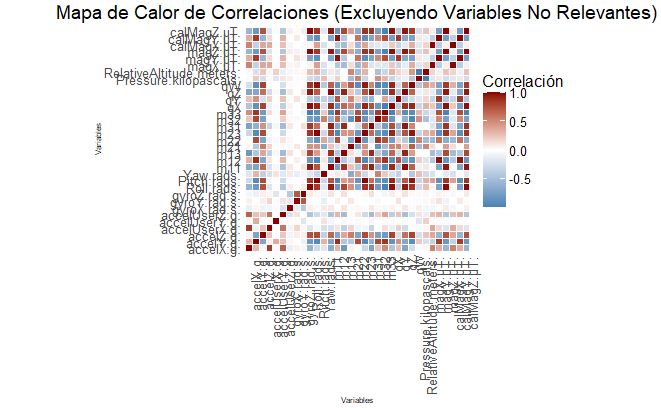

```r
library(ggplot2)
library(reshape2)

# Convertir la matriz en formato largo
corr_melted <- melt(cor_matrix)

# Crear el heatmap
ggplot(corr_melted, aes(x = Var1, y = Var2, fill = value)) +
  geom_tile(color = "white") +
  scale_fill_gradient2(low = "steelblue", high = "darkred", mid = "white", midpoint = 0, name = "Correlación") +
  theme_minimal(base_size = 6) +  # Aumentar el tamaño del texto
  theme(
    axis.text.x = element_text(angle = 90, hjust = 1, size = 10),
    axis.text.y = element_text(size = 10),
    plot.title = element_text(hjust = 0.5, size = 14),
    legend.text = element_text(size = 10),
    legend.title = element_text(size = 12)
  ) +
  labs(
    title = "Mapa de Calor de Correlaciones (Excluyendo Variables No Relevantes)",
    x = "Variables",
    y = "Variables"
  ) +
  coord_fixed()
```

```r
NA
NA
```

#### Variables con Correlaciones Negativas Fuertes

1. **Yaw.rads. y Pitch.rads.**:
   - Estas variables tienen correlaciones negativas significativas con algunas variables de las matrices de orientación. Esto indica que capturan movimientos inversos como cabeceo (Pitch) y guiñada (Yaw), lo que puede ser útil en modelos que analicen dinámicas espaciales.
2. **magZ.µT y calMagZ.µT**:
   - Presentan correlaciones negativas notables con otras dimensiones del campo magnético. Esto puede deberse a la orientación de estas componentes en un eje opuesto.

### Conclusiones y Recomendaciones

1. **Agrupación y Selección de Variables**:
   - Las matrices de orientación (m11 a m33) y las variables de campos magnéticos (magX.µT, magY.µT, magZ.µT y sus calibraciones) deberían ser reducidas seleccionando una o dos variables representativas.
2. **Transformaciones Adicionales**:
   - Considera invertir el signo de variables con correlaciones opuestas como magZ.µT para facilitar la interpretación.
   - Variables como Pitch.rads. y Yaw.rads. podrían beneficiarse de una normalización para analizar su comportamiento dinámico.
3. **Preparación para Modelos**:
   - Antes de entrenar modelos, realiza una revisión final para asegurar que las variables seleccionadas no incluyan redundancias y escalarlas si es necesario.

### **Analisisis de Colinealidad**

A partir del análisis de correlaciones realizado en el dataset, se ha identificado que algunas variables presentan relaciones fuertes entre sí, lo que sugiere la presencia de **colinealidad**. Este fenómeno ocurre cuando dos o más variables predictoras están altamente correlacionadas, lo que puede afectar negativamente la estabilidad y la interpretabilidad del modelo.

Dado que el dataset incluye múltiples mediciones de aceleración, velocidad angular y variables derivadas de sensores, es importante realizar un análisis de colinealidad para:

1. **Identificar variables redundantes:** Detectar aquellas características que contienen información duplicada o muy similar, lo que puede generar sobreajuste en modelos predictivos.
2. **Reducir la dimensionalidad del problema:** Determinar si es necesario eliminar o transformar variables para mejorar la eficiencia del modelo.
3. **Evitar problemas en algoritmos sensibles a la colinealidad:** Modelos como la regresión logística, SVM y redes neuronales pueden verse afectados por la presencia de colinealidad, lo que puede distorsionar la estimación de coeficientes y afectar la capacidad de generalización.

```r
library(dplyr)

# Verificar que el dataset existe
if (exists("data")) {
  # Filtrar las variables numéricas y eliminar la variable dependiente (ActivityType)
  num_data_filtered <- data %>%
    select(where(is.numeric)) %>%
    mutate(dummy_target = runif(nrow(.), 0, 1)) # Crear una variable dummy temporal

  # Validar si hay suficientes variables para calcular el modelo
  if (ncol(num_data_filtered) > 1) {
    # Crear un modelo de regresión con las variables predictoras
    vif_model <- lm(dummy_target ~ ., data = num_data_filtered)

    # Calcular los valores de VIF
    vif_values <- vif(vif_model)

    # Imprimir los valores de VIF
    print("### Factores de Inflación de Varianza (VIF)")
    print(vif_values)

    # Identificar variables con alta colinealidad (VIF > 10 como umbral común)
    high_vif <- vif_values[vif_values > 10]
    if (length(high_vif) > 0) {
      cat("\nVariables con alta colinealidad (VIF > 10):\n")
      print(high_vif)
    } else {
      cat("\nNo se encontraron variables con alta colinealidad (VIF <= 10).\n")
    }
  } else {
    cat("No hay suficientes variables numéricas para calcular el VIF.\n")
  }
} else {
  cat("El dataset 'data' no existe en el entorno.\n")
}
```

```
[1] "### Factores de Inflación de Varianza (VIF)"
               accelX.g.                accelY.g.                accelZ.g.            accelUserX.g.            accelUserY.g.            accelUserZ.g.             gyroX.rad.s.
            8.733330e+01             2.608260e+02             8.566246e+01             3.460002e+01             3.248765e+01             3.713753e+01             1.837560e+00
            gyroY.rad.s.             gyroZ.rad.s.               Roll.rads.              Pitch.rads.                Yaw.rads.                      m11                      m12
            5.561060e+00             6.605426e+00             2.182991e+04             1.049086e+05             4.408982e+00             6.647708e+04             7.274985e+04
                     m13                      m21                      m22                      m23                      m31                      m32                      m33
            3.752650e+04             1.961237e+04             3.358480e+04             6.910820e+04             3.020731e+04             3.501855e+04             9.278336e+04
                      qX                       qY                       qZ                       qW    Pressure.kilopascals. RelativeAltitude.meters.                 magX.µT.
            8.214175e+05             9.320610e+04             2.845493e+05             3.770148e+05             3.430845e+04             3.441654e+04             9.861400e+01
                magY.µT.                 magZ.µT.              calMagX.µT.              calMagY.µT.              calMagZ.µT.
            6.786514e+02             7.504290e+02             1.929854e+02             1.510614e+03             1.483461e+03

Variables con alta colinealidad (VIF > 10):
               accelX.g.                accelY.g.                accelZ.g.            accelUserX.g.            accelUserY.g.            accelUserZ.g.               Roll.rads.
                87.33330                260.82603                 85.66246                 34.60002                 32.48765                 37.13753              21829.90719
             Pitch.rads.                      m11                      m12                      m13                      m21                      m22                      m23
            104908.63400              66477.08206              72749.85314              37526.49710              19612.36802              33584.79896              69108.20105
                     m31                      m32                      m33                       qX                       qY                       qZ                       qW
             30207.30659              35018.55450              92783.36067             821417.54223              93206.10346             284549.33756             377014.84153
   Pressure.kilopascals. RelativeAltitude.meters.                 magX.µT.                 magY.µT.                 magZ.µT.              calMagX.µT.              calMagY.µT.
             34308.45450              34416.54257                 98.61400                678.65136                750.42901                192.98541               1510.61375
             calMagZ.µT.
              1483.46126
```

#### **Resumen General**

Los VIF indican un alto nivel de colinealidad en varias variables del dataset, especialmente en aquellas relacionadas con:

1. **Matrices de orientación (m11 a m33)**.
2. **Componentes cuaterniónicas (qX, qY, qZ, qW)**.
3. **Sensores ambientales (Pressure.kilopascals., RelativeAltitude.meters.)**.
4. **Campos magnéticos (magX.µT, magY.µT, magZ.µT y sus calibradas)**.

### **Recomendaciones Generales**

1. **Reducción Manual de Variables**:
   - **Matrices de Orientación (m11 a m33)**: Conservar solo una o dos variables representativas.
   - **Campos Magnéticos**: Seleccionar una versión calibrada o no calibrada.
   - **Ángulos de Rotación**: Conservar únicamente un ángulo (por ejemplo, `Yaw.rads.`) si es más relevante.
2. **Técnicas Automáticas de Reducción**:
   - Si se desea evitar la selección manual, se puede aplicar **PCA (Análisis de Componentes Principales)** para reducir la dimensionalidad mientras se preserva la variabilidad clave.
3. **Eliminación de Variables de Alta Colinealidad**:
   - Variables con VIF extremos (>1000) como `qX`, `qY`, `qZ`, `qW` o `Pitch.rads.` deben ser eliminadas o transformadas antes de incluirlas en cualquier modelo estadístico o de machine learning.
4. **Validación Posterior**:
   - Tras la eliminación o transformación de variables, es necesario recalcular los VIF para asegurar que se ha mitigado la colinealidad de manera efectiva.

**Extensión del Análisis: Relaciones Dinámicas entre las Fases del Cycling**

Dado que el análisis de correlaciones confirmó la existencia de dependencias entre ciertas variables clave, se decide ampliar el estudio hacia la evaluación de relaciones dinámicas entre las distintas fases de la actividad Cycling. Aunque los datos disponibles corresponden exclusivamente a esta actividad, el análisis de estas relaciones permitirá comprender mejor cómo evolucionan las variables dinámicas durante las diferentes fases de movimiento.

```r
colnames(data)
```

```
 [1] "Timestamp"                "accelX.g."                "accelY.g."                "accelZ.g."                "accelUserX.g."            "accelUserY.g."            "accelUserZ.g."
 [8] "gyroX.rad.s."             "gyroY.rad.s."             "gyroZ.rad.s."             "Roll.rads."               "Pitch.rads."              "Yaw.rads."                "m11"
[15] "m12"                      "m13"                      "m21"                      "m22"                      "m23"                      "m31"                      "m32"
[22] "m33"                      "qX"                       "qY"                       "qZ"                       "qW"                       "ActivityType"             "ActivityConfidence"
[29] "Pressure.kilopascals."    "RelativeAltitude.meters." "magX.µT."                 "magY.µT."                 "magZ.µT."                 "calMagX.µT."              "calMagY.µT."
[36] "calMagZ.µT."
```

```r
# Crear etiquetas de fases de la actividad basadas en altitud relativa
cycling_data_copy <- data %>%
  mutate(ActivityPhase = case_when(
    accelX.g. < 0.5 ~ "Inicio",
    accelX.g. >= 0.5 & accelX.g. < 1.5 ~ "Esfuerzo Moderado",
    accelX.g. >= 1.5 ~ "Esfuerzo Alto",
    TRUE ~ "Otro"
  ))

# Verificar la distribución
table(cycling_data_copy$ActivityPhase)
```

```
    Esfuerzo Alto Esfuerzo Moderado            Inicio
               12              2723               250
```

```r
correlations_by_phase <- cycling_data_copy %>%
  group_by(ActivityPhase) %>%
  summarise(
    Correlation_AccelX_Pitch = cor(accelX.g., Pitch.rads., use = "complete.obs"),
    Correlation_AccelY_Roll = cor(accelY.g., Roll.rads., use = "complete.obs"),
    Correlation_AccelZ_Yaw = cor(accelZ.g., Yaw.rads., use = "complete.obs")
  )

print(correlations_by_phase)
```

| ActivityPhase | Correlation_AccelX_Pitch | Correlation_AccelY_Roll | Correlation_AccelZ_Yaw |
| --- | --- | --- | --- |
| Esfuerzo Alto | 0.1874165 | 0.03688569 | 0.200343816 |
| Esfuerzo Moderado | 0.1420920 | -0.77804663 | -0.417473464 |
| Inicio | -0.2593417 | -0.68781759 | -0.001385577 |

```r
NA
```

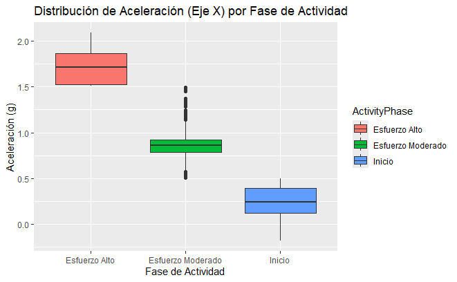

```r
library(ggplot2)
#Representar la distribución y relación de variables dinámicas en cada fase.
ggplot(cycling_data_copy, aes(x = ActivityPhase, y = accelX.g., fill = ActivityPhase)) +
  geom_boxplot() +
  labs(title = "Distribución de Aceleración (Eje X) por Fase de Actividad",
       x = "Fase de Actividad", y = "Aceleración (g)")
```

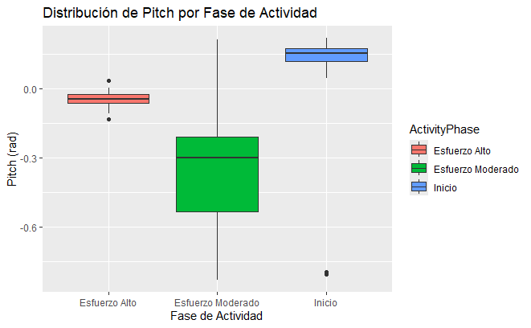

```r
ggplot(cycling_data_copy, aes(x = ActivityPhase, y = Pitch.rads., fill = ActivityPhase)) +
  geom_boxplot() +
  labs(title = "Distribución de Pitch por Fase de Actividad",
       x = "Fase de Actividad", y = "Pitch (rad)")
```

```r
NA
NA
```

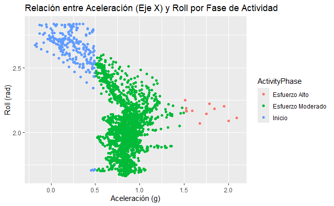

```r
# Explorar gráficamente cómo interactúan las variables clave durante cada fase.
ggplot(cycling_data_copy, aes(x = accelX.g., y = Roll.rads., color = ActivityPhase)) +
  geom_point() +
  labs(
    title = "Relación entre Aceleración (Eje X) y Roll por Fase de Actividad",
    x = "Aceleración (g)",
    y = "Roll (rad)"
  )
```

```r
NA
NA
```

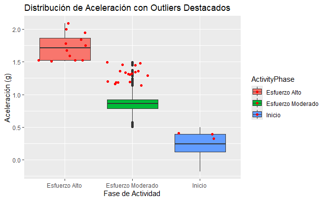

```r
# Filtrar datos de outliers previamente detectados
outliers_data <- cycling_data_copy %>%
  filter(row_number() %in% outlier_indices)

# Comparar distribuciones de variables clave entre datos generales y outliers
ggplot(cycling_data_copy, aes(x = ActivityPhase, y = accelX.g., fill = ActivityPhase)) +
  geom_boxplot() +
  geom_jitter(data = outliers_data, aes(y = accelX.g.), color = "red") +
  labs(
    title = "Distribución de Aceleración con Outliers Destacados",
    x = "Fase de Actividad",
    y = "Aceleración (g)"
  )
```

1. **Segmentación de Actividad y Variables Clave**:
   - Las fases de actividad (Inicio, Esfuerzo Moderado, Esfuerzo Alto) muestran patrones claros y diferenciados en las variables de aceleración (accelX.g.) y orientación (Pitch.rads., Roll.rads.), lo que valida la relevancia de estas variables en la caracterización dinámica del ciclismo.
   - **accelX.g.** y **Pitch.rads.** son variables importantes para identificar transiciones entre fases de esfuerzo, ya que reflejan cambios en la intensidad y la postura del ciclista.
2. **Comportamiento de Outliers**:
   - Los outliers detectados previamente son consistentes con el análisis por fases. En particular, las fases de Esfuerzo Moderado y Esfuerzo Alto contienen valores extremos que parecen reflejar eventos significativos, como cambios bruscos en la dinámica del pedaleo o ajustes al terreno.
   - Esto valida el análisis previo de outliers como indicador de eventos reales y no simplemente ruido, por lo que estos valores podrían aportar información valiosa para la predicción de actividades.
3. **Correlaciones Destacadas**:
   - La correlación fuerte y negativa entre **accelY.g.** y **Roll.rads.** en las fases de Inicio y Esfuerzo Moderado sugiere que el balanceo es altamente dependiente de la aceleración lateral. Esta relación podría ser clave para modelos que predicen el tipo de transporte o la dinámica del ciclista.
   - Las correlaciones entre **accelZ.g.** y **Yaw.rads.** en Esfuerzo Moderado sugieren que los cambios en aceleración vertical influyen en los giros, lo cual podría ser relevante para identificar maniobras específicas.
4. **Variables Relevantes para Modelos de Predicción**:
   - **Aceleración**: Las variables **accelX.g.**, **accelY.g.**, y **accelZ.g.** son importantes para capturar los cambios de intensidad y dirección del movimiento.
   - **Orientación**: **Pitch.rads.**, **Roll.rads.**, y **Yaw.rads.** son cruciales para reflejar el comportamiento dinámico en diferentes fases.
   - **ActivityPhase**: La segmentación de las fases aporta una dimensión temporal que mejora la contextualización de los datos.
5. **Implicaciones para Modelos Predictivos**:
   - La combinación de variables de aceleración y orientación, junto con la segmentación por fases, proporciona un marco sólido para predecir el tipo de transporte o la dinámica específica del ciclista.
   - Los outliers no deben eliminarse automáticamente, ya que parecen reflejar eventos significativos que podrían enriquecer la capacidad predictiva del modelo.

# 9. Resumen y Conclusiones

### 9.1 Resumen del Análisis Realizado

#### Análisis Exploratorio de la Naturaleza de los Datos

- Se identificaron **outliers en múltiples variables clave**, principalmente en `Yaw.rads.`, `gyroZ(rad/s)`, `gyroY(rad/s)`, `accelUserX(g)`, `accelUserY(g)`, `qZ` y `Pitch(rads)`, con una frecuencia superior al 10%.
- Se utilizó **el método IQR y distancias de Mahalanobis** para detectar valores extremos, encontrando **33 observaciones atípicas (1.1%)**.
- Se identificaron **patrones dinámicos en la actividad de ciclismo**, con aceleraciones y velocidades angulares mostrando relaciones significativas en diferentes fases del movimiento.
- No se detectaron valores nulos en el dataset, por lo que no fue necesario aplicar técnicas de imputación.

### 9.2 Conclusiones

#### 1. Detección y Manejo de Outliers

- Variables como `Yaw.rads.`, `gyroZ(rad/s)`, `Pitch(rads)`, y `qZ` presentan valores extremos asociados a cambios bruscos en la dinámica del pedaleo.
- Los outliers fueron identificados pero **no se eliminaron ni se imputaron**, ya que reflejan eventos reales dentro de la actividad ciclística.
- Se sugiere explorar la aplicación de **winsorización o transformaciones logarítmicas** en futuras etapas de modelado para mitigar su impacto sin perder información valiosa.

### 9.3 **Flujo de Transformación de Datos**

1. Evaluar la aplicación de **winsorización o transformaciones logarítmicas** en variables con alta presencia de outliers, como `Yaw.rads.`, `gyroZ(rad/s)`, y `qZ`, para mejorar la estabilidad del modelo.
2. Refinar la selección de variables para mitigar el efecto de la colinealidad alta en `qX`, `qY`, `qZ`, `qW`, y `m11 - m33`. Se evaluará la aplicación de **reducción de dimensionalidad mediante PCA** para conservar solo las variables más informativas. Alternativamente, si la colinealidad es excesiva (VIF > 1000), se considerará la eliminación de algunas de estas variables para evitar redundancia en el modelo.
3. Implementar estrategias de escalado adaptadas al modelo final, usando **RobustScaler para datos con alta dispersión** y **Min-Max Scaling en variables con rangos controlados**.
4. Desarrollar pruebas de validación del modelo considerando distintas combinaciones de transformación de datos y selección de variables para determinar el mejor rendimiento en la clasificación del tipo de transporte.

# 10. Descarga de dataset

```r
head(data)  # Primeras 6 filas
```

|  | Timestamp | accelX.g. | accelY.g. | accelZ.g. | accelUserX.g. | accelUserY.g. | accelUserZ.g. | gyroX.rad.s. | gyroY.rad.s. | gyroZ.rad.s. | Roll.rads. | Pitch.rads. | Yaw.rads. | m11 | m12 | m13 | m21 | m22 | m23 | m31 | m32 | m33 | qX | qY | qZ | qW | ActivityType | ActivityConfidence | Pressure.kilopascals. | … |
| --- | --- | --- | --- | --- | --- | --- | --- | --- | --- | --- | --- | --- | --- | --- | --- | --- | --- | --- | --- | --- | --- | --- | --- | --- | --- | --- | --- | --- | --- | --- |
| 1 | 2020-09-11 23:12:12 | 0.7491 | 0.0179 | 0.6625 | 0.0155 | -0.0749 | 0.0835 | -0.9299 | 0.6129 | 0.4261 | 2.2264 | -0.0904 | -3.0885 | 0.6050 | 0.1038 | -0.7894 | 0.0529 | -0.9945 | -0.0903 | -0.7945 | 0.0129 | -0.6072 | 0.8954 | 0.0438 | -0.4422 | -0.0288 | Cycling | Med | 100.7013 | … |
| 2 | 2020-09-11 23:12:12 | 0.6866 | 0.0033 | 0.6448 | -0.0595 | -0.0679 | 0.0408 | -0.9055 | 0.7696 | 0.4283 | 2.2338 | -0.0815 | -3.0841 | 0.6108 | 0.0994 | -0.7855 | 0.0573 | -0.9950 | -0.0814 | -0.7897 | 0.0047 | -0.6134 | 0.8971 | 0.0437 | -0.4390 | -0.0240 | Cycling | Med | 100.7013 | … |
| 3 | 2020-09-11 23:12:12 | 0.6620 | 0.0041 | 0.6479 | -0.1046 | -0.0700 | 0.0234 | -0.9136 | 0.8444 | 0.4377 | 2.2422 | -0.0726 | -3.0796 | 0.6174 | 0.0952 | -0.7809 | 0.0618 | -0.9955 | -0.0725 | -0.7842 | -0.0035 | -0.6205 | 0.8991 | 0.0436 | -0.4352 | -0.0192 | Cycling | Med | 100.7013 | … |
| 4 | 2020-09-11 23:12:12 | 0.6586 | -0.0060 | 0.6743 | -0.1169 | -0.0601 | 0.0248 | -0.9047 | 0.8827 | 0.4589 | 2.2511 | -0.0634 | -3.0755 | 0.6244 | 0.0907 | -0.7758 | 0.0659 | -0.9958 | -0.0634 | -0.7783 | -0.0115 | -0.6278 | 0.9011 | 0.0434 | -0.4312 | -0.0144 | Cycling | Med | 100.7013 | … |
| 5 | 2020-09-11 23:12:12 | 0.6758 | -0.0239 | 0.7278 | -0.1088 | -0.0658 | 0.0534 | -0.8597 | 0.9453 | 0.4900 | 2.2605 | -0.0543 | -3.0717 | 0.6318 | 0.0862 | -0.7703 | 0.0697 | -0.9961 | -0.0542 | -0.7720 | -0.0194 | -0.6354 | 0.9032 | 0.0431 | -0.4269 | -0.0096 | Cycling | Med | 100.7013 | … |
| 6 | 2020-09-11 23:12:12 | 0.7100 | -0.0396 | 0.7727 | -0.0799 | -0.0732 | 0.0999 | -0.8061 | 1.0124 | 0.5312 | 2.2704 | -0.0451 | -3.0688 | 0.6397 | 0.0812 | -0.7643 | 0.0726 | -0.9963 | -0.0451 | -0.7652 | -0.0267 | -0.6433 | 0.9054 | 0.0425 | -0.4223 | -0.0051 | Cycling | Med | 100.7013 | … |

```r
tail(data)  # Últimas 6 filas
```

|  | Timestamp | accelX.g. | accelY.g. | accelZ.g. | accelUserX.g. | accelUserY.g. | accelUserZ.g. | gyroX.rad.s. | gyroY.rad.s. | gyroZ.rad.s. | Roll.rads. | Pitch.rads. | Yaw.rads. | m11 | m12 | m13 | m21 | m22 | m23 | m31 | m32 | m33 | qX | qY | qZ | qW | ActivityType | ActivityConfidence | Pressure.kilopascals. | … |
| --- | --- | --- | --- | --- | --- | --- | --- | --- | --- | --- | --- | --- | --- | --- | --- | --- | --- | --- | --- | --- | --- | --- | --- | --- | --- | --- | --- | --- | --- | --- |
| 2980 | 2020-09-11 23:12:42 | 0.8036 | 0.5508 | 0.1507 | -0.0083 | -0.0181 | 0.0563 | -0.2106 | 0.1499 | 0.0136 | 1.6701 | -0.5963 | 2.7022 | 0.3274 | 0.4635 | -0.8234 | -0.3520 | -0.7488 | -0.5616 | -0.8769 | 0.4737 | -0.0820 | 0.7345 | 0.0380 | -0.5787 | -0.3523 | Cycling | High | 100.7023 | … |
| 2981 | 2020-09-11 23:12:42 | 0.7941 | 0.5644 | 0.1652 | -0.0240 | -0.0054 | 0.0712 | -0.2372 | 0.1777 | 0.0207 | 1.6736 | -0.5956 | 2.7048 | 0.3290 | 0.4622 | -0.8235 | -0.3502 | -0.7501 | -0.5610 | -0.8770 | 0.4730 | -0.0849 | 0.7355 | 0.0381 | -0.5780 | -0.3514 | Cycling | High | 100.7023 | … |
| 2982 | 2020-09-11 23:12:42 | 0.8014 | 0.5676 | 0.1671 | -0.0290 | 0.0060 | 0.0795 | -0.2262 | 0.1433 | 0.0292 | 1.6770 | -0.5949 | 2.7074 | 0.3306 | 0.4609 | -0.8236 | -0.3484 | -0.7514 | -0.5604 | -0.8771 | 0.4722 | -0.0878 | 0.7365 | 0.0382 | -0.5773 | -0.3505 | Cycling | High | 100.7023 | … |
| 2983 | 2020-09-11 23:12:42 | 0.8200 | 0.5660 | 0.1576 | -0.0178 | 0.0072 | 0.0756 | -0.1828 | 0.0352 | 0.0330 | 1.6794 | -0.5941 | 2.7098 | 0.3314 | 0.4601 | -0.8237 | -0.3468 | -0.7526 | -0.5598 | -0.8775 | 0.4712 | -0.0898 | 0.7372 | 0.0384 | -0.5769 | -0.3496 | Cycling | High | 100.7023 | … |
| 2984 | 2020-09-11 23:12:42 | 0.8423 | 0.5674 | 0.1405 | 0.0031 | 0.0071 | 0.0623 | -0.1148 | -0.0942 | 0.0430 | 1.6802 | -0.5934 | 2.7114 | 0.3311 | 0.4597 | -0.8241 | -0.3458 | -0.7535 | -0.5592 | -0.8780 | 0.4701 | -0.0905 | 0.7374 | 0.0386 | -0.5770 | -0.3489 | Cycling | High | 100.7023 | … |
| 2985 | 2020-09-11 23:12:42 | 0.8539 | 0.5684 | 0.1221 | 0.0229 | 0.0093 | 0.0449 | -0.0579 | -0.1412 | 0.0462 | 1.6796 | -0.5927 | 2.7122 | 0.3299 | 0.4597 | -0.8245 | -0.3453 | -0.7542 | -0.5586 | -0.8786 | 0.4690 | -0.0900 | 0.7372 | 0.0388 | -0.5775 | -0.3484 | Cycling | High | 100.7023 | … |

```r
str(data)  # Muestra estructura del dataset
```

```
'data.frame':   2985 obs. of  36 variables:
 $ Timestamp               : POSIXct, format: "2020-09-11 23:12:12" "2020-09-11 23:12:12" "2020-09-11 23:12:12" "2020-09-11 23:12:12" ...
 $ accelX.g.               : num  0.749 0.687 0.662 0.659 0.676 ...
 $ accelY.g.               : num  0.0179 0.0033 0.0041 -0.006 -0.0239 ...
 $ accelZ.g.               : num  0.662 0.645 0.648 0.674 0.728 ...
 $ accelUserX.g.           : num  0.0155 -0.0595 -0.1046 -0.1169 -0.1088 ...
 $ accelUserY.g.           : num  -0.0749 -0.0679 -0.07 -0.0601 -0.0658 ...
 $ accelUserZ.g.           : num  0.0835 0.0408 0.0234 0.0248 0.0534 ...
 $ gyroX.rad.s.            : num  -0.93 -0.905 -0.914 -0.905 -0.86 ...
 $ gyroY.rad.s.            : num  0.613 0.77 0.844 0.883 0.945 ...
 $ gyroZ.rad.s.            : num  0.426 0.428 0.438 0.459 0.49 ...
 $ Roll.rads.              : num  2.23 2.23 2.24 2.25 2.26 ...
 $ Pitch.rads.             : num  -0.0904 -0.0815 -0.0726 -0.0634 -0.0543 -0.0451 -0.0359 -0.0267 -0.0173 -0.0079 ...
 $ Yaw.rads.               : num  -3.09 -3.08 -3.08 -3.08 -3.07 ...
 $ m11                     : num  0.605 0.611 0.617 0.624 0.632 ...
```

[output cut: 22 more lines]

```r
write.csv(data, "dataset_resultante_cycling.csv", row.names = FALSE)
```